# LendingClubLoanDefaultClassification

Vikas Pulpa

2022-12-08

#### **1. Read the csv into a tibble data structure**

```r
lendingClubData  <- read_csv('E:\\OneDrive - Microsoft\\StatisticsMasters\\STAT656\\Homework\\Project\\Task3\\Data\\LoanStats3a.csv')
```

#### **2. Looking at the data parsing issues and cleaning up the excel file**

```r
problems(lendingClubData)
```

```
## # A tibble: 1 × 5
##     row   col expected actual                                   file
##   <int> <int> <chr>    <chr>                                    <chr>
## 1 39789     1 a double Loans that do not meet the credit policy ""
```

On examining the excel sheet, we observed that the lines 39788 and 39789 were blank except that it indicates the subsequent rows indicate that loan where granted out of policy.

Therefore, we edited the excel to:

- Deleted those two rows 39788 and 39789 from excel.
- Added a new feature IsLoanMeetsPolicy that takes value of ‘Yes’ for the loans that meet the policy (first 39786 rows) and ‘No’ for the ones that don’t.

#### **3. Read the new csv into a tibble data structure**

```r
lendingClubData  <- read_csv(
                              'E:\\OneDrive - Microsoft\\StatisticsMasters\\STAT656\\Homework\\Project\\Task3\\Data\\LoanStats3aCleaned.csv'
                             ,show_col_types = FALSE
                            )

lendingClubData  <- read.csv(
                               'E:\\OneDrive - Microsoft\\StatisticsMasters\\STAT656\\Homework\\Project\\Task3\\Data\\LoanStats3aCleaned.csv'
                             , stringsAsFactors = FALSE
                             , na.strings=c("","NA")
                            )
lendingClubData <-  as_tibble(lendingClubData) #convert it to tibble
```

#### **4. Explore the Data**

```r
dim(lendingClubData)
```

```
## [1] 42535   112
```

```r
#lendingClubData
```

#### **5. Data Pre-Processing**

##### **5. a. Look at the data structures**

```r
table(sapply(lendingClubData[1,],class))
```

```
##
## character   integer   logical   numeric
##        25        19        54        14
```

##### **5. b. Look at the missing values and perform Featurewise imputation**

```r
ggplot_missing <- function(x){

    #### This function produces a plot of the missing data pattern in x.  It is a modified version of a function in the 'neato' package

  my_colors <- RColorBrewer::brewer.pal(12, "Paired")[6:7]

  x %>%
    is.na %>%
    melt %>%
    ggplot(data = ., aes(x = Var2, y = Var1)) +
      geom_raster(aes(fill = value)) +
      #scale_fill_brewer(name = "", labels = c("Present","Missing"), palette="Paired", direction = -1) +
      scale_fill_manual(name = "", labels = c("Present","Missing"), values = c(my_colors[2], my_colors[1])) +
      theme_minimal() +
      theme(axis.text.x  = element_text(angle=45, vjust=0.5)) +
      labs(x = "Variables in Dataset", y = "Rows / observations")
}
```

```r
getMode <- function(v) {
   uniqv <- unique(v)
   uniqv[which.max(tabulate(match(v, uniqv)))]
}
```

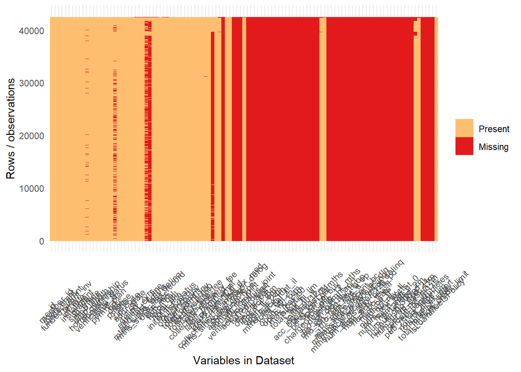

```r
ggplot_missing(lendingClubData %>% dplyr::select(-loan_status))
```

```r
featureCount <- rep(0, 5)
for(i in 1:5) {
  featureCount[i] <-  sum(ifelse(sapply(lendingClubData, function(x){ sum(is.na(x))*100./nrow(lendingClubData) }) <= i * 10.0 , 1, 0))
}
```

```r
PercentageOfNullValues <- c('10 % or less', '20 % or less', '30 % or less', '40 % or less', '50 % or less')
(missingValueColumns <- data.frame (PercentageOfNullValues, featureCount))
```

```
##   PercentageOfNullValues featureCount
## 1           10 % or less           54
## 2           20 % or less           54
## 3           30 % or less           54
## 4           40 % or less           55
## 5           50 % or less           55
```

```r
columnVector <- ifelse(sapply(lendingClubData, function(x){ sum(is.na(x))*100./nrow(lendingClubData) }) <= 50.0 , 1, 0)
```

```r
lendingClubDataReduced <- lendingClubData %>% select_if(columnVector == 1)
dim(lendingClubDataReduced)
```

```
## [1] 42535    55
```

```r
ggplot_missing(lendingClubDataReduced)
```

[figure not shown]

##### **5. c. Remove the unnecessary columns based on the row count**

```r
numericColumns   <- names(lendingClubDataReduced) [sapply(lendingClubDataReduced[1, ], class) == "numeric"]
integerColumns   <- names(lendingClubDataReduced) [sapply(lendingClubDataReduced[1, ], class) == "integer"]
characterColumns <- names(lendingClubDataReduced) [sapply(lendingClubDataReduced[1, ], class) == "character"]
logicalColumns   <- names(lendingClubDataReduced) [sapply(lendingClubDataReduced[1, ], class) == "logical"]
```

```r
sapply(lendingClubDataReduced[, characterColumns], function(x) {length(unique(x))})
```

```
##                term            int_rate               grade           sub_grade
##                   2                 394                   7                  35
##           emp_title          emp_length      home_ownership verification_status
##               30661                  12                   5                   3
##             issue_d         loan_status          pymnt_plan                 url
##                  55                   9                   2               42535
##                desc             purpose               title            zip_code
##               28965                  14               21255                 837
##          addr_state    earliest_cr_line          revol_util initial_list_status
##                  50                 531                1120                   1
##        last_pymnt_d  last_credit_pull_d    application_type   IsLoanMeetsPolicy
##                 106                 111                   1                   2
```

```r
lendingClubDataReduced <- lendingClubDataReduced %>%
                           dplyr::select( - c(
                                                 emp_title, verification_status, pymnt_plan, url, desc, title, zip_code
                                               , last_pymnt_d, application_type, initial_list_status
                                              )
                                        )
```

```r
sapply(lendingClubDataReduced[, integerColumns], function(x) {length(unique(x))})
```

```
##                         id                  member_id
##                      42535                      42535
##                  loan_amnt                funded_amnt
##                        898                       1051
##                delinq_2yrs             inq_last_6mths
##                         13                         29
##                   open_acc                    pub_rec
##                         45                          7
##                  revol_bal                  total_acc
##                      22709                         84
## collections_12_mths_ex_med                policy_code
##                          2                          1
##             acc_now_delinq   chargeoff_within_12_mths
##                          3                          2
##                delinq_amnt       pub_rec_bankruptcies
##                          4                          4
##                  tax_liens
##                          3
```

```r
lendingClubDataReduced <- lendingClubDataReduced %>%
                           dplyr::select( - c(member_id, policy_code, -collections_12_mths_ex_med) )
```

##### **5. d. Remove the unnecessary columns after looking at the data dictionary**

The following features are not required since we are classifying the risk of default before the loan is funded. *Note, we will keep installment to see if the user defaults for the given installment.

```r
featureList              <- c(
                                'funded_amnt',             'funded_amnt_inv', 'int_rate',           'issue_d',       'out_prncp',          'out_prncp_inv'
                               ,'total_pymnt',             'total_pymnt_inv', 'total_rec_prncp',    'total_rec_int', 'total_rec_late_fee', 'recoveries'
                               ,'collection_recovery_fee', 'last_pymnt_amnt'
                             )

lendingClubDataReduced   <- lendingClubDataReduced %>% dplyr::select(-all_of(featureList))
```

```r
lendingClubDataReducedNumeric <- lendingClubDataReduced[,sapply(lendingClubDataReduced, class) != 'character']
zeroSumColumns <- colnames(lendingClubDataReducedNumeric[,colSums(lendingClubDataReducedNumeric,na.rm = TRUE)==0])
zeroSumColumns
```

```
## [1] "collections_12_mths_ex_med" "chargeoff_within_12_mths"
```

```r
lendingClubDataReduced <- lendingClubDataReduced %>%
                            dplyr::select(-all_of(zeroSumColumns))
```

```r
numericColumns   <- names(lendingClubDataReduced) [sapply(lendingClubDataReduced[1, ], class) == "numeric"]
integerColumns   <- names(lendingClubDataReduced) [sapply(lendingClubDataReduced[1, ], class) == "integer"]
characterColumns <- names(lendingClubDataReduced) [sapply(lendingClubDataReduced[1, ], class) == "character"]
```

##### **5. e. Variable Cleanup**

The following columns have wrong date format. Therefore changing them to the correct format: * earliest_cr_line * last_credit_pull_d

```r
## Format(1): Month-Year: Jan-00
lendingClubDataReduced_1                           <- lendingClubDataReduced %>%
                                                        filter(str_detect(earliest_cr_line, c("^J|^F|^M|^A|^S|^O|^N|^D")))

## Format(2): Year-Month: 1-Jan
lendingClubDataReduced_2  <- lendingClubDataReduced %>%
                              filter(str_detect(earliest_cr_line, c("^1|^2|^3|^4|^5|^6|^7|^8|^9|^10|^11|^12|^13|^14|^15|^16|^17|^18|^19|^20")))

# Convert the format of earliest_cr_line to Date
lendingClubDataReduced_1$earliest_cr_line         <- as.Date(sub("$","-01",lendingClubDataReduced_1$earliest_cr_line), "%b-%y-%d")
lendingClubDataReduced_2$earliest_cr_line         <- as.Date(sub("^","01-",lendingClubDataReduced_2$earliest_cr_line), "%d-%y-%b")

lendingClubDataReduced_ecl_Changed                <- bind_rows(lendingClubDataReduced_1,lendingClubDataReduced_2)

lendingClubDataReduced_Remaining                  <- anti_join(lendingClubDataReduced, lendingClubDataReduced_ecl_Changed, by = 'id')
lendingClubDataReduced_Remaining$earliest_cr_line <- as.Date(lendingClubDataReduced_Remaining$earliest_cr_line)

lendingClubDataReduced                            <- bind_rows(lendingClubDataReduced_1,lendingClubDataReduced_2,lendingClubDataReduced_Remaining)
```

```r
## Format(1): Month-Year: Jan-00
lendingClubDataReduced_1                           <- lendingClubDataReduced %>%
                                                        filter(str_detect(last_credit_pull_d, c("^J|^F|^M|^A|^S|^O|^N|^D")))

## Format(2): Year-Month: 1-Jan
lendingClubDataReduced_2  <- lendingClubDataReduced %>%
                              filter(str_detect(last_credit_pull_d, c("^1|^2|^3|^4|^5|^6|^7|^8|^9|^10|^11|^12|^13|^14|^15|^16|^17|^18|^19|^20")))

# Convert the format of earliest_cr_line to Date
lendingClubDataReduced_1$last_credit_pull_d         <- as.Date(sub("$","-01",lendingClubDataReduced_1$last_credit_pull_d), "%b-%y-%d")
lendingClubDataReduced_2$last_credit_pull_d         <- as.Date(sub("^","01-",lendingClubDataReduced_2$last_credit_pull_d), "%d-%y-%b")

lendingClubDataReduced_lcp_Changed                  <- bind_rows(lendingClubDataReduced_1,lendingClubDataReduced_2)

lendingClubDataReduced_Remaining                    <- anti_join(lendingClubDataReduced, lendingClubDataReduced_lcp_Changed, by = 'id')
lendingClubDataReduced_Remaining$last_credit_pull_d <- as.Date(lendingClubDataReduced_Remaining$last_credit_pull_d)

lendingClubDataReduced                              <- bind_rows(lendingClubDataReduced_1,lendingClubDataReduced_2,lendingClubDataReduced_Remaining)
```

```r
lendingClubDataReduced <- lendingClubDataReduced %>%
                            select(-id)
```

##### **5. f. Datatype Formatting & Conversion**

1. Format:
- term
- loan_status
- revol_util
- emp_length

```r
lendingClubDataCleaned  <- lendingClubDataReduced %>%
                              mutate(term = str_replace(term, "months", "")) %>%
                              mutate_at("term", as.numeric) %>%
                              mutate(loan_status = str_replace(loan_status, "Does not meet the credit policy. Status:", "")) %>%
                              mutate(emp_length = str_replace_all(
                                                                  emp_length,
                                                                  c('< 1 year' = '0 years' , '10\\+ years' = '10 years', "n/a" = NA, "years" = "", "year" = "")                                                                   )
                                     ) %>%
                              mutate_at("emp_length", as.numeric) %>%
                              mutate(revol_util = str_replace(revol_util, "%", "")) %>%
                              mutate_at("revol_util", as.numeric)
```

```r
numericColumns   <- names(lendingClubDataCleaned) [sapply(lendingClubDataCleaned[1, ], class) == "numeric"]
integerColumns   <- names(lendingClubDataReduced) [sapply(lendingClubDataReduced[1, ], class) == "integer"]
characterColumns <- names(lendingClubDataCleaned) [sapply(lendingClubDataCleaned[1, ], class) == "character"]
```

##### **5. g. Numeric Features Imputation**

```r
missingValueColumns <- data.frame(sapply(lendingClubDataCleaned, function(x){ sum(is.na(x))*100./nrow(lendingClubData) }))
missingValueColumns <- cbind(variable = row.names(missingValueColumns), missingValueColumns)

names(missingValueColumns) <- c("MissingValueColumn", "MissingValuePercent")
missingValueColumns %>%
  dplyr::filter(MissingValuePercent != 0) %>%
  arrange(desc(MissingValuePercent))
```

```
##                        MissingValueColumn MissingValuePercent
## pub_rec_bankruptcies pub_rec_bankruptcies          3.20912190
## emp_length                     emp_length          2.61431762
## tax_liens                       tax_liens          0.24685553
## revol_util                     revol_util          0.21159045
## delinq_2yrs                   delinq_2yrs          0.06817915
## earliest_cr_line         earliest_cr_line          0.06817915
## inq_last_6mths             inq_last_6mths          0.06817915
## open_acc                         open_acc          0.06817915
## pub_rec                           pub_rec          0.06817915
## total_acc                       total_acc          0.06817915
## acc_now_delinq             acc_now_delinq          0.06817915
## delinq_amnt                   delinq_amnt          0.06817915
## annual_inc                     annual_inc          0.00940402
## last_credit_pull_d     last_credit_pull_d          0.00940402
```

For the following columns NA might indicate that the data entry operator might have inputted nothing or there is not value to be entered for the applicant.

- pub_rec_bankruptcies has only 3 values {0, 1, 2} with most of the values 0.
- tax_liens has only 2 values {0, 1} with most of the values 0.
- delinq_2yrs.
- inq_last_6mths
- pub_rec
- acc_now_delinq has only 2 values {0, 1} with most of the values 0.
- delinq_amnt

Therefore replacing NA with 0

```r
lendingClubDataImputed <- lendingClubDataCleaned %>%
                            mutate(pub_rec_bankruptcies = if_else(is.na(pub_rec_bankruptcies), 0L, pub_rec_bankruptcies)) %>%
                            mutate(tax_liens = if_else(is.na(tax_liens), 0L, tax_liens)) %>%
                            mutate(delinq_2yrs = if_else(is.na(delinq_2yrs), 0L, delinq_2yrs)) %>%
                            mutate(inq_last_6mths = if_else(is.na(inq_last_6mths), 0L, inq_last_6mths)) %>%
                            mutate(pub_rec = if_else(is.na(pub_rec), 0L, pub_rec)) %>%
                            mutate(acc_now_delinq = if_else(is.na(acc_now_delinq), 0L, acc_now_delinq)) %>%
                            mutate(delinq_amnt = if_else(is.na(delinq_amnt), 0L, acc_now_delinq))
```

Performing the mean/median/mode/quantile imputation for the following columns:

- emp_length
- revol_util
- open_acc
- total_acc
- annual_inc

```r
summary(lendingClubDataImputed$emp_length)
```

```
##    Min. 1st Qu.  Median    Mean 3rd Qu.    Max.    NA's
##   0.000   2.000   4.000   4.923   9.000  10.000    1112
```

```r
quantile(lendingClubDataImputed$emp_length, na.rm = TRUE)
```

```
##   0%  25%  50%  75% 100%
##    0    2    4    9   10
```

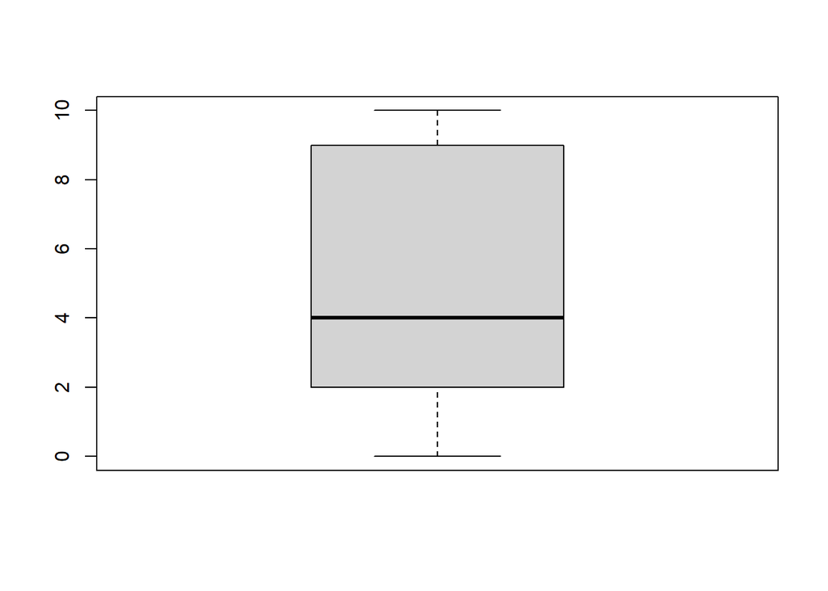

```r
boxplot(lendingClubDataImputed$emp_length)
```

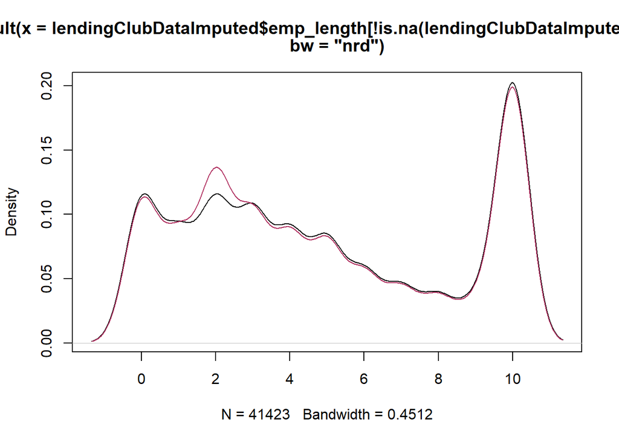

```r
plot(density(lendingClubDataImputed$emp_length[!is.na(lendingClubDataImputed$emp_length)], bw = "nrd"))


lendingClubDataImputed <- lendingClubDataImputed %>%
                            mutate(emp_length = if_else(is.na(emp_length), quantile(emp_length, na.rm = TRUE)[2] , emp_length))

points(density(lendingClubDataImputed$emp_length[!is.na(lendingClubDataImputed$emp_length)], bw = "nrd"), type = "l", col = "maroon")
```

```r
summary(lendingClubDataImputed$revol_util)
```

```
##    Min. 1st Qu.  Median    Mean 3rd Qu.    Max.    NA's
##    0.00   25.70   49.70   49.12   72.70  119.00      90
```

```r
quantile(lendingClubDataImputed$revol_util, na.rm = TRUE)
```

```
##    0%   25%   50%   75%  100%
##   0.0  25.7  49.7  72.7 119.0
```

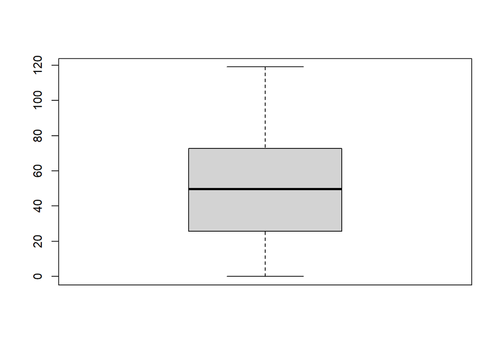

```r
boxplot(lendingClubDataImputed$revol_util)
```

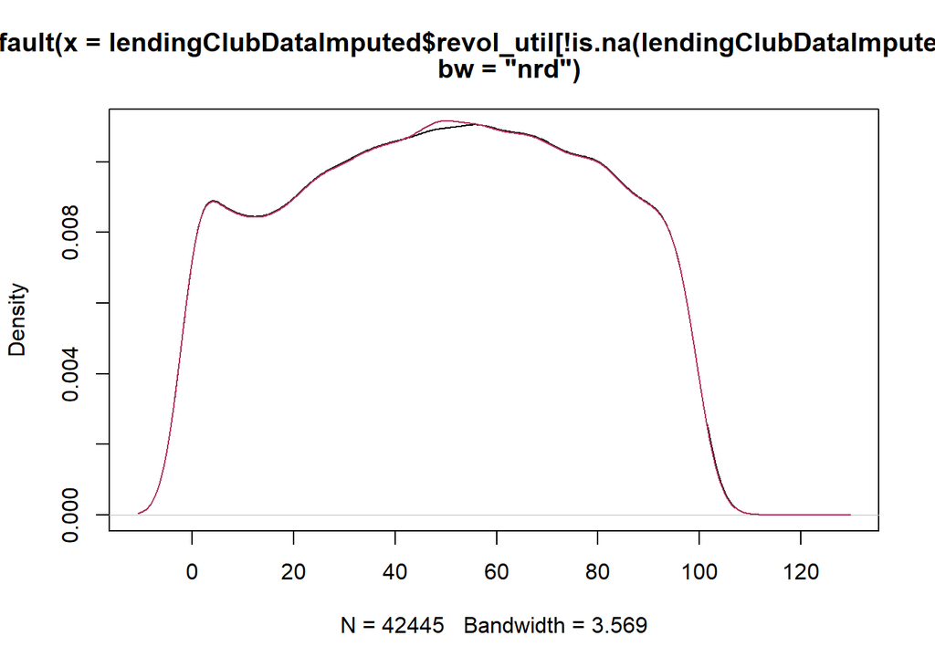

```r
plot(density(lendingClubDataImputed$revol_util[!is.na(lendingClubDataImputed$revol_util)], bw = "nrd"))


lendingClubDataImputed <- lendingClubDataImputed %>%
                           mutate(revol_util = if_else(is.na(revol_util), mean(revol_util, na.rm = TRUE) , revol_util))

points(density(lendingClubDataImputed$revol_util[!is.na(lendingClubDataImputed$revol_util)], bw = "nrd"), type = "l", col = "maroon")
```

```r
summary(lendingClubDataImputed$open_acc)
```

```
##    Min. 1st Qu.  Median    Mean 3rd Qu.    Max.    NA's
##   1.000   6.000   9.000   9.344  12.000  47.000      29
```

```r
quantile(lendingClubDataImputed$open_acc, na.rm = TRUE)
```

```
##   0%  25%  50%  75% 100%
##    1    6    9   12   47
```

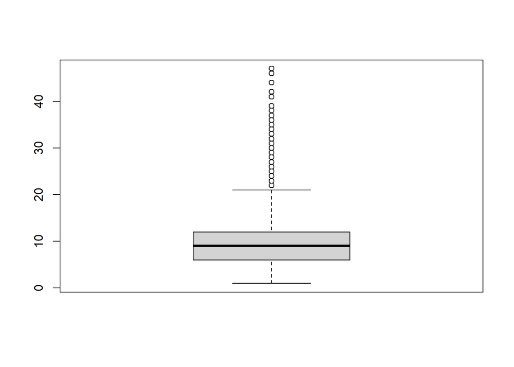

```r
boxplot(lendingClubDataImputed$open_acc)
```

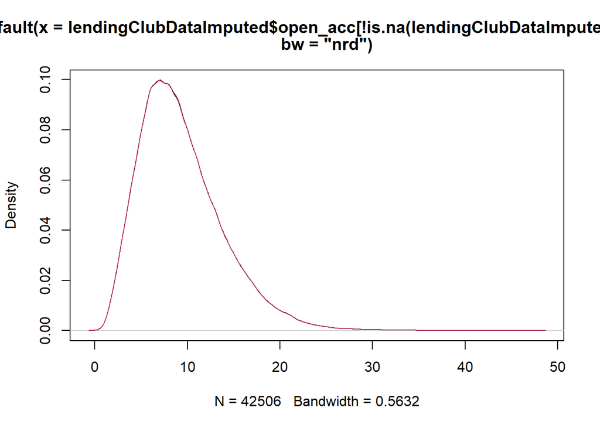

```r
plot(density(lendingClubDataImputed$open_acc[!is.na(lendingClubDataImputed$open_acc)], bw = "nrd"))


lendingClubDataImputed <- lendingClubDataImputed %>%
                           mutate(open_acc = if_else(is.na(open_acc), as.integer(median(open_acc, na.rm = TRUE)), open_acc))

points(density(lendingClubDataImputed$open_acc[!is.na(lendingClubDataImputed$open_acc)], bw = "nrd"), type = "l", col = "maroon")
```

```r
summary(lendingClubDataImputed$total_acc)
```

```
##    Min. 1st Qu.  Median    Mean 3rd Qu.    Max.    NA's
##    1.00   13.00   20.00   22.12   29.00   90.00      29
```

```r
quantile(lendingClubDataImputed$total_acc, na.rm = TRUE)
```

```
##   0%  25%  50%  75% 100%
##    1   13   20   29   90
```

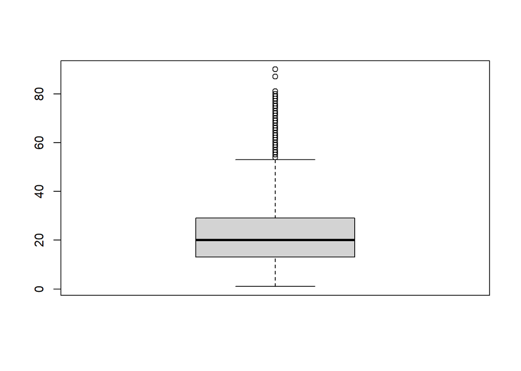

```r
boxplot(lendingClubDataImputed$total_acc)
```

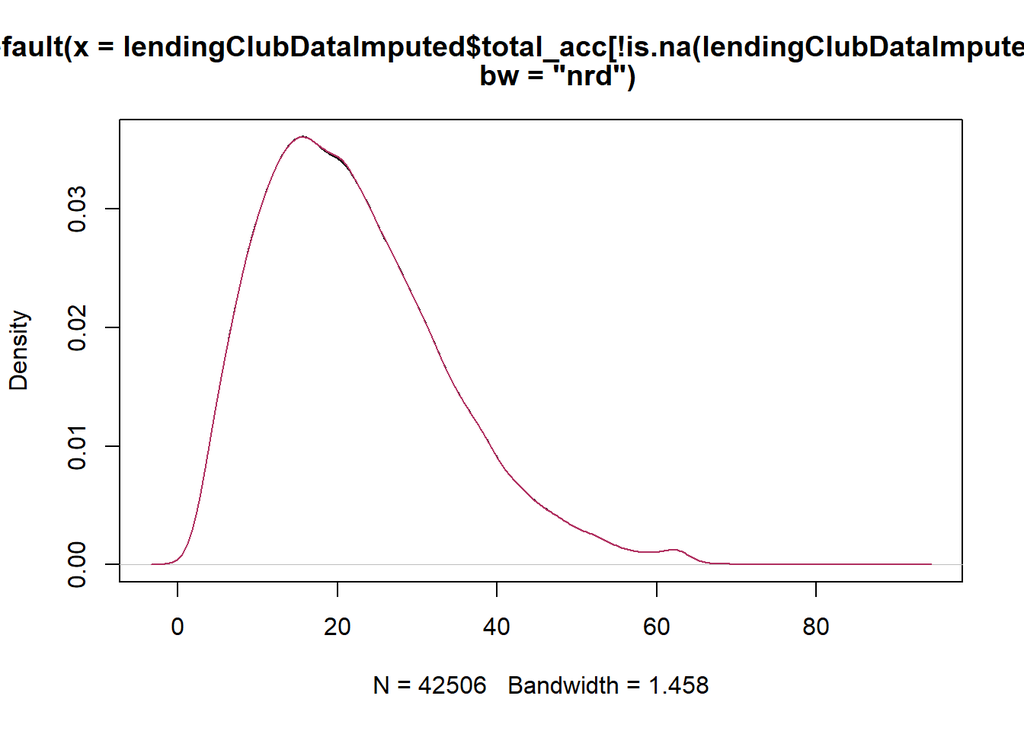

```r
plot(density(lendingClubDataImputed$total_acc[!is.na(lendingClubDataImputed$total_acc)], bw = "nrd"))


lendingClubDataImputed <- lendingClubDataImputed %>%
                           mutate(total_acc = if_else(is.na(total_acc), as.integer(median(total_acc, na.rm = TRUE)), total_acc))

points(density(lendingClubDataImputed$total_acc[!is.na(lendingClubDataImputed$total_acc)], bw = "nrd"), type = "l", col = "maroon")
```

```r
summary(lendingClubDataImputed$annual_inc)
```

```
##    Min. 1st Qu.  Median    Mean 3rd Qu.    Max.    NA's
##    1896   40000   59000   69137   82500 6000000       4
```

```r
quantile(lendingClubDataImputed$annual_inc, na.rm = TRUE)
```

```
##      0%     25%     50%     75%    100%
##    1896   40000   59000   82500 6000000
```

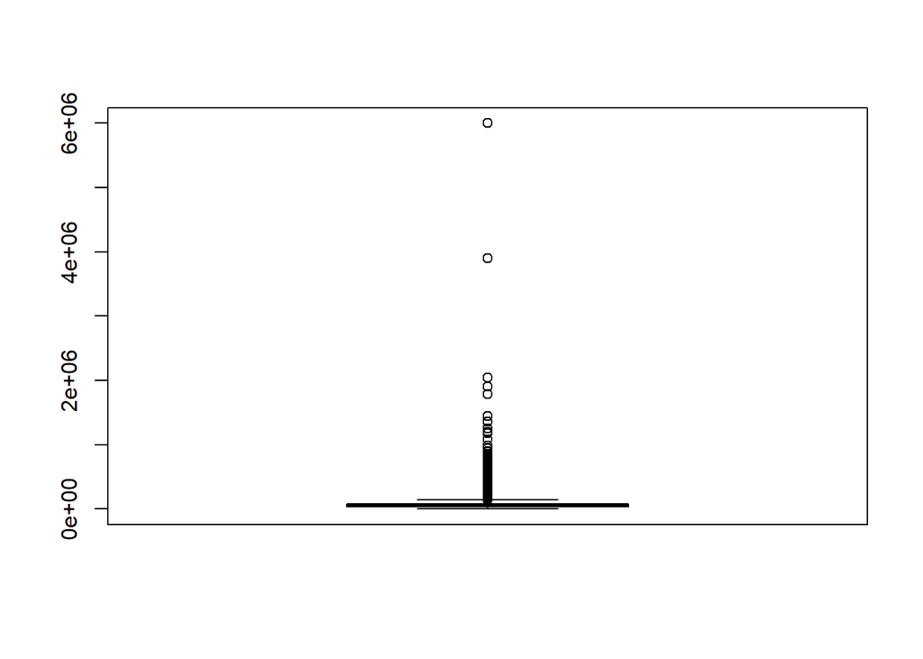

```r
boxplot(lendingClubDataImputed$annual_inc)
```

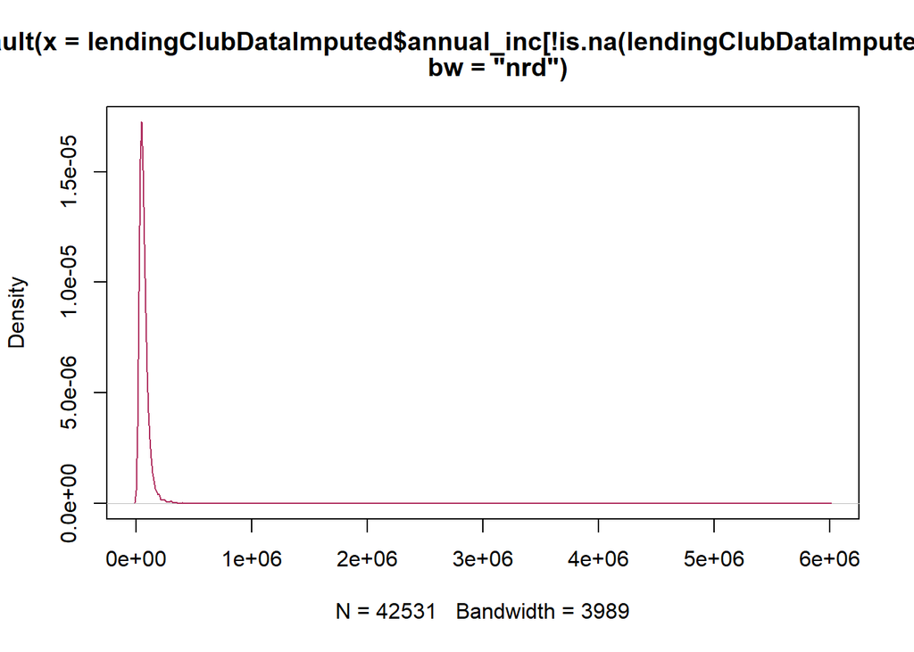

```r
plot(density(lendingClubDataImputed$annual_inc[!is.na(lendingClubDataImputed$annual_inc)], bw = "nrd"))


lendingClubDataImputed <- lendingClubDataImputed %>%
                           mutate(annual_inc = if_else(is.na(annual_inc), median(annual_inc, na.rm = TRUE) , annual_inc))

points(density(lendingClubDataImputed$annual_inc[!is.na(lendingClubDataImputed$annual_inc)], bw = "nrd"), type = "l", col = "maroon")
```

```r
lendingClubDataImputed <- lendingClubDataImputed %>%
                            mutate(earliest_cr_line   = if_else(is.na(earliest_cr_line), getMode(earliest_cr_line), earliest_cr_line))  %>%
                            mutate(last_credit_pull_d = if_else(is.na(last_credit_pull_d), getMode(last_credit_pull_d), last_credit_pull_d))
```

```r
lendingClubDataImputed <- lendingClubDataImputed %>%
                            mutate(lastCreditPulledYear = format(last_credit_pull_d, "%Y"))%>%
                            mutate(earliestCreditLineYear = format(earliest_cr_line, "%Y"))
```

```r
dim(lendingClubDataImputed)
```

```
## [1] 42535    28
```

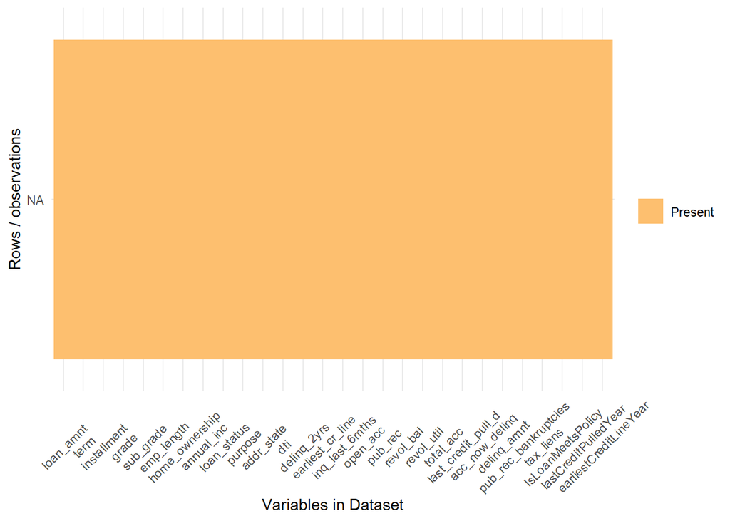

```r
ggplot_missing(lendingClubDataImputed)
```

##### **6. Univariate Analysis**

##### **6. a. Looking at feature that have low SD**

```r
skim(lendingClubDataImputed)
```

Data summary

| Name | lendingClubDataImputed |
| --- | --- |
| Number of rows | 42535 |
| Number of columns | 28 |
| _______________________ |  |
| Column type frequency: |  |
| character | 9 |
| Date | 2 |
| numeric | 17 |
| ________________________ |  |
| Group variables | None |

**Variable type: character**

| skim_variable | n_missing | complete_rate | min | max | empty | n_unique | whitespace |
| --- | --- | --- | --- | --- | --- | --- | --- |
| grade | 0 | 1 | 1 | 1 | 0 | 7 | 0 |
| sub_grade | 0 | 1 | 2 | 2 | 0 | 35 | 0 |
| home_ownership | 0 | 1 | 3 | 8 | 0 | 5 | 0 |
| loan_status | 0 | 1 | 7 | 18 | 0 | 7 | 0 |
| purpose | 0 | 1 | 3 | 18 | 0 | 14 | 0 |
| addr_state | 0 | 1 | 2 | 2 | 0 | 50 | 0 |
| IsLoanMeetsPolicy | 0 | 1 | 2 | 3 | 0 | 2 | 0 |
| lastCreditPulledYear | 0 | 1 | 4 | 4 | 0 | 10 | 0 |
| earliestCreditLineYear | 0 | 1 | 4 | 4 | 0 | 53 | 0 |

**Variable type: Date**

| skim_variable | n_missing | complete_rate | min | max | median | n_unique |
| --- | --- | --- | --- | --- | --- | --- |
| earliest_cr_line | 0 | 1 | 1969-02-01 | 2068-12-01 | 1998-06-01 | 530 |
| last_credit_pull_d | 0 | 1 | 2007-05-01 | 2016-08-01 | 2015-04-01 | 110 |

**Variable type: numeric**

| skim_variable | n_missing | complete_rate | mean | sd | p0 | p25 | p50 | p75 | p100 | hist |
| --- | --- | --- | --- | --- | --- | --- | --- | --- | --- | --- |
| loan_amnt | 0 | 1 | 11089.72 | 7410.94 | 500.00 | 5200.00 | 9700.00 | 15000.00 | 35000.00 | ▇▇▃▂▁ |
| term | 0 | 1 | 42.21 | 10.51 | 36.00 | 36.00 | 36.00 | 60.00 | 60.00 | ▇▁▁▁▃ |
| installment | 0 | 1 | 322.62 | 208.93 | 15.67 | 165.52 | 277.69 | 428.18 | 1305.19 | ▇▆▂▁▁ |
| emp_length | 0 | 1 | 4.85 | 3.55 | 0.00 | 2.00 | 4.00 | 9.00 | 10.00 | ▇▅▃▂▆ |
| annual_inc | 0 | 1 | 69135.60 | 64093.41 | 1896.00 | 40000.00 | 59000.00 | 82500.00 | 6000000.00 | ▇▁▁▁▁ |
| dti | 0 | 1 | 13.37 | 6.73 | 0.00 | 8.20 | 13.47 | 18.68 | 29.99 | ▅▇▇▆▁ |
| delinq_2yrs | 0 | 1 | 0.15 | 0.51 | 0.00 | 0.00 | 0.00 | 0.00 | 13.00 | ▇▁▁▁▁ |
| inq_last_6mths | 0 | 1 | 1.08 | 1.53 | 0.00 | 0.00 | 1.00 | 2.00 | 33.00 | ▇▁▁▁▁ |
| open_acc | 0 | 1 | 9.34 | 4.49 | 1.00 | 6.00 | 9.00 | 12.00 | 47.00 | ▇▃▁▁▁ |
| pub_rec | 0 | 1 | 0.06 | 0.25 | 0.00 | 0.00 | 0.00 | 0.00 | 5.00 | ▇▁▁▁▁ |
| revol_bal | 0 | 1 | 14297.86 | 22018.44 | 0.00 | 3635.00 | 8821.00 | 17251.00 | 1207359.00 | ▇▁▁▁▁ |
| revol_util | 0 | 1 | 49.12 | 28.33 | 0.00 | 25.80 | 49.60 | 72.60 | 119.00 | ▇▇▇▇▁ |
| total_acc | 0 | 1 | 22.12 | 11.59 | 1.00 | 13.00 | 20.00 | 29.00 | 90.00 | ▇▇▂▁▁ |
| acc_now_delinq | 0 | 1 | 0.00 | 0.01 | 0.00 | 0.00 | 0.00 | 0.00 | 1.00 | ▇▁▁▁▁ |
| delinq_amnt | 0 | 1 | 0.00 | 0.01 | 0.00 | 0.00 | 0.00 | 0.00 | 1.00 | ▇▁▁▁▁ |
| pub_rec_bankruptcies | 0 | 1 | 0.04 | 0.21 | 0.00 | 0.00 | 0.00 | 0.00 | 2.00 | ▇▁▁▁▁ |
| tax_liens | 0 | 1 | 0.00 | 0.00 | 0.00 | 0.00 | 0.00 | 0.00 | 1.00 | ▇▁▁▁▁ |

##### **6. b. Looking at relationship between feature and supervisor and also the features that have low SD**

Filtering the data so that we have only “Charged Off” and “Fully Paid” loan statuses. The rest of the loan statuses does not help in classification.

```r
lendingClubDataFiltered <- lendingClubDataImputed %>% dplyr::filter(loan_status %in% c("Charged Off", "Fully Paid"))
```

From the data analysis, we can remove the following columns: * acc_now_delinq * delinq_amnt * tax_liens

```r
lendingClubDataFiltered <- lendingClubDataFiltered %>% dplyr::select(-c(acc_now_delinq, delinq_amnt, tax_liens))
```

##### **7.Variability Check**

```r
nearZeroVarRes <- nearZeroVar(lendingClubDataFiltered, saveMetrics = TRUE)
nearZeroVarRes[nearZeroVarRes$zeroVar == TRUE | nearZeroVarRes$nzv == TRUE, ]
```

```
##                      freqRatio percentUnique zeroVar  nzv
## pub_rec_bankruptcies  21.89786   0.007193727   FALSE TRUE
```

##### **8. Correlation Filtering**

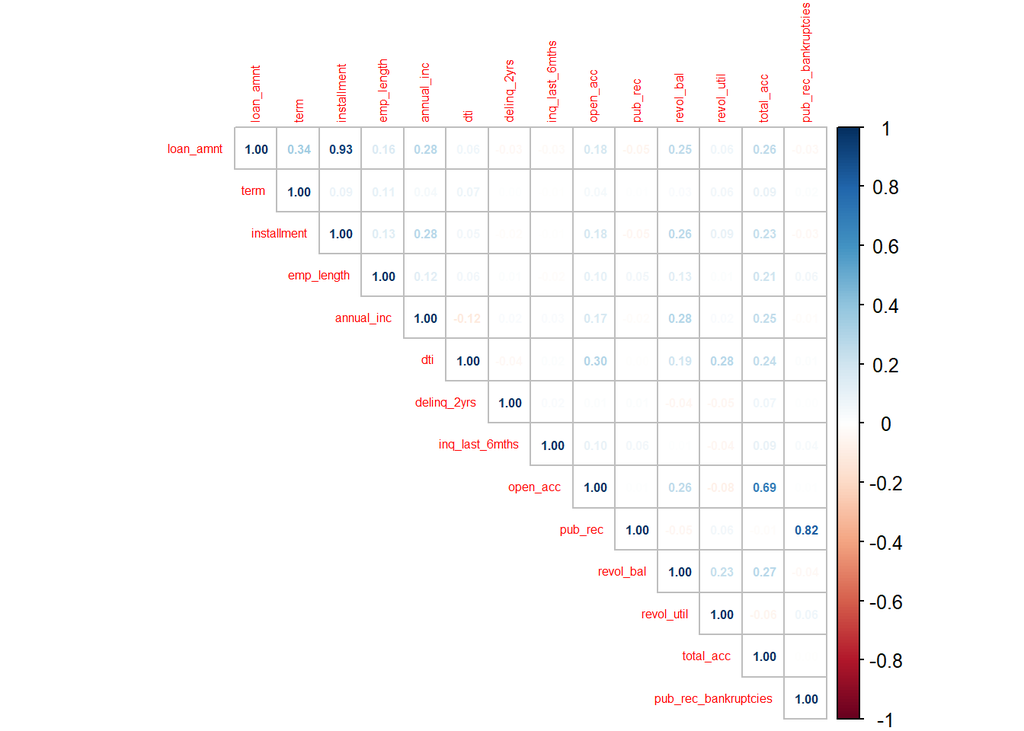

```r
quantitativeColumns   <- names(lendingClubDataFiltered) [
                                                            sapply(lendingClubDataFiltered[1, ], class) == "numeric" |
                                                            sapply(lendingClubDataFiltered[1, ], class) == "integer"
                                                        ]

corrleation           <- cor(lendingClubDataFiltered[, quantitativeColumns], use="pairwise.complete.obs", method="pearson")
corrplot(corrleation, method='number', type = 'upper', tl.cex=.5, number.cex=0.5)
```

```r
highlyCorrelatedFeature           <- findCorrelation(corrleation, 0.80, names = TRUE)
highlyCorrelatedFeature
```

```
## [1] "loan_amnt"            "pub_rec_bankruptcies"
```

```r
lendingClubDataFilteredWithoutCor  <- lendingClubDataFiltered %>%
                                        dplyr::select(-pub_rec_bankruptcies, -installment, -total_acc)
dim(lendingClubDataFilteredWithoutCor)
```

```
## [1] 41703    22
```

- Charged Off Loans are associated with higher mean Loan Amount.
- 60-month-term loans are twice likely to be Charged Off compared to 36-month-term loan.
- Charged Off Loans are associated with higher mean Installment Amount.
- There is higher probability of charge off as the sub_grade goes from A to G
- Renters and homeowners have a higher probability of charge-off.
- Charged Off Loans are associated with lower mean Annual Income.
- Small Businesses(Purpose) seem to have a higher charge off probability for loans.
- Charged Off Loans are associated with higher mean dti.
- Charged Off Loans are associated with higher number of deliquent account in past two years.
- Charged Off Loans are associated with higher number of inquires in past 6 months.
- Charged Off Loans are associated with higher number of inquires in past 6 months.
- Charged Off Loans are associated with higher number of public records.
- Charged Off Loans are associated with higher revolving balance utilization (revol_util).
- Borrowers who are charged-off tend to have shorter lines of credit.
- Borrowers who are charged-off tend to have the credit pulled recently.
- Decided to addr_state as it might bias the results in favor of some states.
- Probability of charge off is almost same across all the employments lengths.
- There is no significant relationship between open_acc and Charge Off rates.
- There is no significant relationship between revol_bal and Charge Off rates.
- There is no significant relationship between total_acc and Charge Off rates.
- acc_now_delinq, delinq_amnt, tax_liens are removed since there are no significant accounts with the data.
- pub_rec_bankruptcies is correlated with number of public records. Removed this feature since it has near zero variance.

```r
lendingClubDataFilteredWithoutCor <- lendingClubDataFilteredWithoutCor %>%
                                       select(-addr_state, -grade)
```

##### **9. Datatype Conversion**

- 1. Look for quantitative variables that are numeric and convert them into numeric.
- 2. Look for qualitative variables that are numeric and convert them into factors.
- 3. Encode the qualitative variables into dummy variables.

```r
## Convert character, numeric and integers into factors

lendingClubDataSet <- lendingClubDataFilteredWithoutCor %>%
                        mutate(term = as.factor(term))  %>%
                        mutate(sub_grade = as.factor(sub_grade)) %>%
                        mutate(emp_length = as.factor(emp_length)) %>%
                        mutate(home_ownership = as.factor(home_ownership)) %>%
                        mutate(loan_status = as.factor(loan_status)) %>%
                        mutate(purpose = as.factor(purpose)) %>%
                        mutate(IsLoanMeetsPolicy = as.factor(IsLoanMeetsPolicy)) %>%
                        mutate(loan_amnt = as.numeric(loan_amnt)) %>%
                        mutate(delinq_2yrs = as.numeric(delinq_2yrs)) %>%
                        mutate(inq_last_6mths = as.numeric(inq_last_6mths)) %>%
                        mutate(open_acc = as.numeric(open_acc)) %>%
                        mutate(pub_rec = as.numeric(pub_rec)) %>%
                        mutate(revol_bal = as.numeric(revol_bal)) %>%
                        mutate(lastCreditPulledYear = as.factor(lastCreditPulledYear)) %>%
                        mutate(earliestCreditLineYear = as.factor(earliestCreditLineYear))
```

```r
table(sapply(lendingClubDataSet[1,],class))
```

```
##
##    Date  factor numeric
##       2       9       9
```

```r
names(lendingClubDataSet)
```

```
##  [1] "loan_amnt"              "term"                   "sub_grade"
##  [4] "emp_length"             "home_ownership"         "annual_inc"
##  [7] "loan_status"            "purpose"                "dti"
## [10] "delinq_2yrs"            "earliest_cr_line"       "inq_last_6mths"
## [13] "open_acc"               "pub_rec"                "revol_bal"
## [16] "revol_util"             "last_credit_pull_d"     "IsLoanMeetsPolicy"
## [19] "lastCreditPulledYear"   "earliestCreditLineYear"
```

```r
dim(lendingClubDataSet)
```

```
## [1] 41703    20
```

##### **10. Splitting the Training & Test Datasets**

```r
set.seed(123)

trainDataIndex <- createDataPartition(lendingClubDataSet$loan_status, p = .7, list = FALSE)

lendingClubTrain   <- lendingClubDataSet[trainDataIndex, ]
lendingClubTest    <- lendingClubDataSet[-trainDataIndex, ]
```

##### **11. Remove Skewness via. transformations**

```r
quantitativeColumns   <- names(lendingClubTrain) [sapply(lendingClubTrain[1, ], class) == "numeric"]
qualitativeColumns    <- names(lendingClubTrain) [sapply(lendingClubTrain[1, ], class) != "numeric"]

skew <- sapply(lendingClubTrain[quantitativeColumns], e1071::skewness)
skew <- abs(skew) > 2
skewedColumns <- names(lendingClubTrain %>% select(all_of(quantitativeColumns)))[skew]
skewedColumns
```

```
## [1] "annual_inc"     "delinq_2yrs"    "inq_last_6mths" "pub_rec"
## [5] "revol_bal"
```

```r
transformedlendingClubTrain <- lendingClubTrain %>%
                                 select(annual_inc, revol_bal) %>%
                                 preProcess(method = 'YeoJohnson') %>%
                                 predict(newdata = lendingClubTrain %>% select(annual_inc, revol_bal))

lendingClubTrain            <- cbind(
                                    lendingClubTrain %>% select(-annual_inc, -revol_bal)
                                   ,transformedlendingClubTrain
                                   )
```

```r
quantitativeColumnsTest   <- names(lendingClubTest) [sapply(lendingClubTest[1, ], class) == "numeric"]
qualitativeColumnsTest    <- names(lendingClubTest) [sapply(lendingClubTest[1, ], class) != "numeric"]

skewTest <- sapply(lendingClubTest[quantitativeColumnsTest], e1071::skewness)
skewTest <- abs(skewTest) > 2
skewedColumnsTest <- names(lendingClubTest %>% select(all_of(quantitativeColumnsTest)))[skewTest]
skewedColumnsTest
```

```
## [1] "annual_inc"     "delinq_2yrs"    "inq_last_6mths" "pub_rec"
## [5] "revol_bal"
```

```r
transformedlendingClubTest <- lendingClubTest %>%
                                 select(annual_inc, revol_bal) %>%
                                 preProcess(method = 'YeoJohnson') %>%
                                 predict(newdata = lendingClubTest %>% select(annual_inc, revol_bal))

lendingClubTest            <- cbind(
                                    lendingClubTest %>% select(-annual_inc, -revol_bal)
                                   ,transformedlendingClubTest
                                   )
```

### **12. Centering and Saling

```r
numericFeaturesTrain       <- lendingClubTrain %>% select_if(is.numeric)
nonNumericFeaturesTrain    <- lendingClubTrain %>% select_if(~!is.numeric(.x))

numericFeaturesTrainScaled <- numericFeaturesTrain %>%
                                preProcess(.) %>%
                                predict(newdata = numericFeaturesTrain)

lendingClubTrain           <- cbind(numericFeaturesTrainScaled, nonNumericFeaturesTrain)
```

```r
numericFeaturesTest       <- lendingClubTest %>% select_if(is.numeric)
nonNumericFeaturesTest    <- lendingClubTest %>% select_if(~!is.numeric(.x))

numericFeaturesTestScaled <- numericFeaturesTest %>%
                                preProcess(.) %>%
                                predict(newdata = numericFeaturesTest)

lendingClubTest           <- cbind(numericFeaturesTestScaled, nonNumericFeaturesTest)
```

```r
dim(lendingClubTrain)
```

```
## [1] 29193    20
```

```r
dim(lendingClubTest)
```

```
## [1] 12510    20
```

##### **13. Supervisor proportions**

```r
  lendingClubTrain %>%
    group_by(loan_status) %>%
    summarise( Count = n() ) %>%
    mutate(percentage = Count/sum(Count) * 100)
```

```
## # A tibble: 2 × 3
##   loan_status Count percentage
##   <fct>       <int>      <dbl>
## 1 Charged Off  4481       15.3
## 2 Fully Paid  24712       84.7
```

#### **14. re-balance the data sets**

- Using Downsampling method, we will re-balance the dataset, since there is some class imbalance: https://www.r-bloggers.com/2019/04/methods-for-dealing-with-imbalanced-data/
- Not able to use SMOTE technique in R, since SMOTE technique needs all the features to be numerical, and it does not work well with encoded categorical data.

```r
lendingClubTrainRebalanced <- downSample(x=lendingClubTrain[,names(lendingClubTrain) != "loan_status"], y=lendingClubTrain$loan_status, yname = "loan_status")

lendingClubTrainRebalancedX  <- lendingClubTrainRebalanced %>% select(-loan_status)
lendingClubTrainRebalancedY  <- lendingClubTrainRebalanced %>% select(loan_status)

lendingClubTrainX            <- lendingClubTrain %>% select(-loan_status)
lendingClubTrainY            <- lendingClubTrain %>% select(loan_status)

lendingClubTestX             <- lendingClubTest %>% select(-loan_status)
lendingClubTestY             <- lendingClubTest %>% select(loan_status)
```

```r
  lendingClubTrainRebalanced %>%
    group_by(loan_status) %>%
    summarise( Count = n() ) %>%
    mutate(percentage = Count/sum(Count) * 100)
```

```
## # A tibble: 2 × 3
##   loan_status Count percentage
##   <fct>       <int>      <dbl>
## 1 Charged Off  4481         50
## 2 Fully Paid   4481         50
```

```r
 lendingClubTest %>%
    group_by(loan_status) %>%
    summarise( Count = n() ) %>%
    mutate(percentage = Count/sum(Count) * 100)
```

```
## # A tibble: 2 × 3
##   loan_status Count percentage
##   <fct>       <int>      <dbl>
## 1 Charged Off  1920       15.3
## 2 Fully Paid  10590       84.7
```

```r
#Removed these columns after running the models.

lendingClubTrainReduced            <- lendingClubTrain            %>% select(-lastCreditPulledYear, -earliestCreditLineYear)
lendingClubTestReduced             <- lendingClubTest             %>% select(-lastCreditPulledYear, -earliestCreditLineYear)
lendingClubTrainRebalancedReduced  <- lendingClubTrainRebalanced  %>% select(-lastCreditPulledYear, -earliestCreditLineYear)

lendingClubTrainXReduced           <- lendingClubTrainX           %>% select(-lastCreditPulledYear, -earliestCreditLineYear)
lendingClubTestXReduced            <- lendingClubTestX            %>% select(-lastCreditPulledYear, -earliestCreditLineYear)
lendingClubTrainRebalancedXReduced <- lendingClubTrainRebalancedX %>% select(-lastCreditPulledYear, -earliestCreditLineYear)
```

## ** Modelling **

#### 1. Logistic regression

```r
set.seed(123)

numericColumns   <- names(lendingClubTrainXReduced) [sapply(lendingClubTrainXReduced[1, ], class) == "numeric"]
factorColumns    <- names(lendingClubTrainXReduced) [sapply(lendingClubTrainXReduced[1, ], class) == "factor"]

XtrainQualitativeFeature  <- select(lendingClubTrainXReduced, all_of(factorColumns))
dummyModel                <- dummyVars(~., data = XtrainQualitativeFeature, fullRank = TRUE)
XtrainQualFeaturesEncoded <- predict(dummyModel, XtrainQualitativeFeature, drop2nd = TRUE)


XTrain        = cbind(
                       XtrainQualFeaturesEncoded
                      ,lendingClubTrainXReduced %>% select(all_of(numericColumns))
                     )

XtrainRebalancedQualitativeFeature  <- select(lendingClubTrainRebalancedXReduced, all_of(factorColumns))
dummyModel                          <- dummyVars(~., data = XtrainRebalancedQualitativeFeature, fullRank = TRUE)
XtrainRebalancedQualFeaturesEncoded <- predict(dummyModel, XtrainRebalancedQualitativeFeature, drop2nd = TRUE)


XTrainRebalanced        = cbind(
                                 XtrainRebalancedQualFeaturesEncoded
                                ,lendingClubTrainRebalancedXReduced %>% select(all_of(numericColumns))
                               )

YtrainRelevel = relevel(lendingClubTrainY$loan_status, ref = 'Charged Off')
YtestRelevel  = relevel(lendingClubTestY$loan_status,  ref = 'Charged Off')

YtrainBalancedRelevel = relevel(lendingClubTrainRebalancedY$loan_status, ref = 'Charged Off')

trControl     = trainControl(method = "cv", number = 10)

outLogistic   = train(
                        x         = XTrain
                      , y         = YtrainRelevel
                      , method    = 'glm'
                      , trControl = trControl
                     )

outLogisticBalanced   = train(
                                x         = XTrainRebalanced
                              , y         = YtrainBalancedRelevel
                              , method    = 'glm'
                              , trControl = trControl
                             )
```

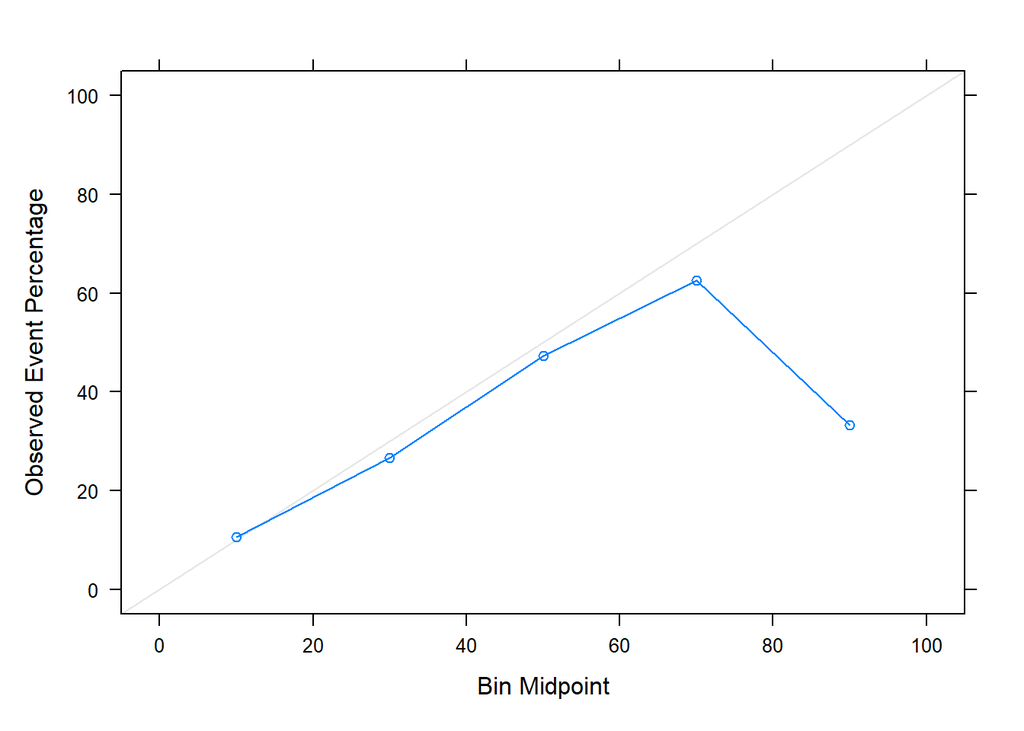

```r
numericColumns   <- names(lendingClubTestXReduced) [sapply(lendingClubTestXReduced[1, ], class) == "numeric"]
factorColumns    <- names(lendingClubTestXReduced) [sapply(lendingClubTestXReduced[1, ], class) == "factor"]

XtestQualitativeFeature  <- select(lendingClubTestXReduced, all_of(factorColumns))
dummyModel               <- dummyVars(~., data = XtestQualitativeFeature, fullRank = TRUE)
XtestQualFeaturesEncoded <- predict(dummyModel, XtestQualitativeFeature, drop2nd = TRUE)

XTest        = cbind(
                       XtestQualFeaturesEncoded
                      ,lendingClubTestXReduced %>% select(all_of(numericColumns))
                     )

YhatTestProbLR = predict(outLogistic, XTest, type = 'prob')

calibProbs = calibration(YtestRelevel ~ YhatTestProbLR$'Charged Off', cuts = 5)
xyplot(calibProbs)
```

```r
YhatTestLR           = predict(outLogistic, XTest, type = 'raw')

confusionMatrixOutLR = confusionMatrix(reference = YtestRelevel, data = YhatTestLR)
confusionMatrixOutLR$overall[1]
```

```
## Accuracy
## 0.846203
```

```r
confusionMatrixOutLR$byClass[7]
```

```
##         F1
## 0.03992016
```

```r
print(confusionMatrixOutLR$table)
```

```
##              Reference
## Prediction    Charged Off Fully Paid
##   Charged Off          40         44
##   Fully Paid         1880      10546
```

```r
print(confusionMatrixOutLR$overall[1:2])
```

```
##   Accuracy      Kappa
## 0.84620304 0.02740643
```

```r
print(confusionMatrixOutLR$byClass[1:2])
```

```
## Sensitivity Specificity
##  0.02083333  0.99584514
```

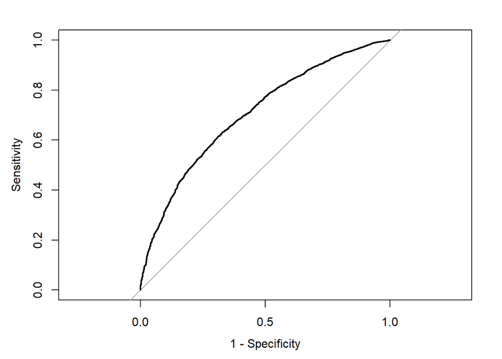

```r
rocCurveLR = roc(lendingClubTestY$loan_status, YhatTestProbLR$'Charged Off')
plot(rocCurveLR, legacy.axes=TRUE)
```

```r
rocCurveLR$auc
```

```
## Area under the curve: 0.7059
```

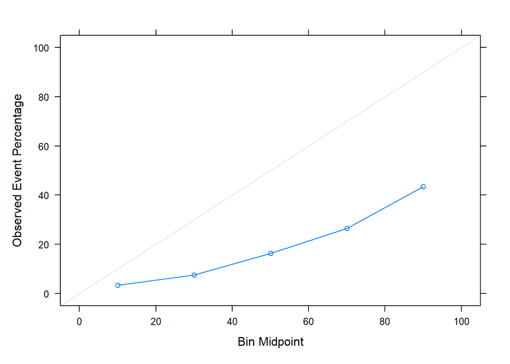

```r
YhatTestProbLRBalanced = predict(outLogisticBalanced, XTest, type = 'prob')

calibProbsBalanced = calibration(YtestRelevel ~ YhatTestProbLRBalanced$'Charged Off', cuts = 5)
xyplot(calibProbsBalanced)
```

```r
YhatTestLRBalanced           = predict(outLogisticBalanced, XTest, type = 'raw')

confusionMatrixOutLRBalanced = confusionMatrix(reference = YtestRelevel, data = YhatTestLRBalanced)
confusionMatrixOutLRBalanced$overall[1]
```

```
##  Accuracy
## 0.6421263
```

```r
confusionMatrixOutLRBalanced$byClass[7]
```

```
##        F1
## 0.3616141
```

```r
print(confusionMatrixOutLRBalanced$table)
```

```
##              Reference
## Prediction    Charged Off Fully Paid
##   Charged Off        1268       3825
##   Fully Paid          652       6765
```

```r
print(confusionMatrixOutLRBalanced$overall[1:2])
```

```
##  Accuracy     Kappa
## 0.6421263 0.1784840
```

```r
print(confusionMatrixOutLRBalanced$byClass[1:2])
```

```
## Sensitivity Specificity
##   0.6604167   0.6388102
```

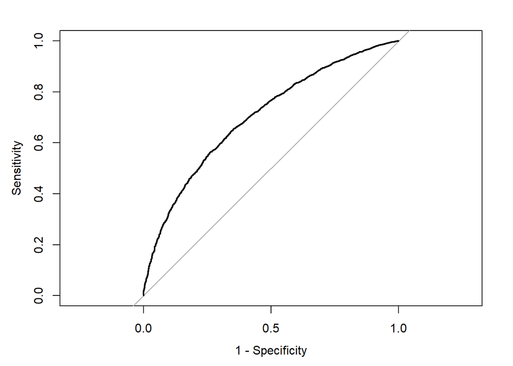

```r
rocCurveLRBalanced = roc(lendingClubTestY$loan_status, YhatTestProbLRBalanced$'Charged Off')
plot(rocCurveLRBalanced, legacy.axes=TRUE)
```

```r
rocCurveLRBalanced$auc
```

```
## Area under the curve: 0.7035
```

### 2. Logistic Elastic Net

```r
set.seed(123)

K            = 10
trainControl = trainControl(method = "cv", number = K)
tuneGrid <- expand.grid(
                         lambda = seq(1e-6, .8 , length = 30)
                        ,alpha  = c(0, 0.25, 0.5, 0.75, 1.0)
                       )

elasticOut   = train(
                       XTrainRebalanced
                     , lendingClubTrainRebalancedY$loan_status
                     , method = "glmnet"
                     , trControl = trainControl
                     , tuneLength = 10
                     #, tuneGrid = tuneGrid
                    )

elasticOut
```

```
## glmnet
##
## 8962 samples
##   72 predictor
##    2 classes: 'Charged Off', 'Fully Paid'
##
## No pre-processing
## Resampling: Cross-Validated (10 fold)
## Summary of sample sizes: 8065, 8066, 8066, 8066, 8065, 8066, ...
## Resampling results across tuning parameters:
##
##   alpha  lambda        Accuracy   Kappa
##   0.1    4.509163e-05  0.6489628  0.2979210
##   0.1    1.041675e-04  0.6489628  0.2979210
##   0.1    2.406405e-04  0.6489628  0.2979210
##   0.1    5.559107e-04  0.6489628  0.2979210
##   0.1    1.284226e-03  0.6492973  0.2985898
##   0.1    2.966728e-03  0.6504126  0.3008215
##   0.1    6.853527e-03  0.6498541  0.2997038
##   0.1    1.583254e-02  0.6499654  0.2999269
##   0.1    3.657521e-02  0.6494077  0.2988117
##   0.1    8.449349e-02  0.6486253  0.2972457
##   0.2    4.509163e-05  0.6489628  0.2979210
##   0.2    1.041675e-04  0.6489628  0.2979210
##   0.2    2.406405e-04  0.6489628  0.2979210
##   0.2    5.559107e-04  0.6488512  0.2976977
##   0.2    1.284226e-03  0.6494089  0.2988137
##   0.2    2.966728e-03  0.6505237  0.3010435
##   0.2    6.853527e-03  0.6500769  0.3001504
##   0.2    1.583254e-02  0.6498532  0.2997020
##   0.2    3.657521e-02  0.6476210  0.2952373
##   0.2    8.449349e-02  0.6410362  0.2820681
##   0.3    4.509163e-05  0.6486280  0.2972513
##   0.3    1.041675e-04  0.6486280  0.2972513
##   0.3    2.406405e-04  0.6486280  0.2972513
##   0.3    5.559107e-04  0.6488512  0.2976978
##   0.3    1.284226e-03  0.6498550  0.2997061
##   0.3    2.966728e-03  0.6511927  0.3023814
##   0.3    6.853527e-03  0.6490719  0.2981398
##   0.3    1.583254e-02  0.6477319  0.2954584
```

[output cut: 60 more lines]

```
##   0.9    3.657521e-02  0.6294308  0.2588598
##   0.9    8.449349e-02  0.5900448  0.1800908
##   1.0    4.509163e-05  0.6485164  0.2970281
##   1.0    1.041675e-04  0.6485164  0.2970281
##   1.0    2.406405e-04  0.6486280  0.2972514
##   1.0    5.559107e-04  0.6508589  0.3017136
##   1.0    1.284226e-03  0.6507463  0.3014895
##   1.0    2.966728e-03  0.6496295  0.2992549
##   1.0    6.853527e-03  0.6476207  0.2952356
##   1.0    1.583254e-02  0.6400325  0.2800607
##   1.0    3.657521e-02  0.6276456  0.2552898
##   1.0    8.449349e-02  0.5900448  0.1800908
##
## Accuracy was used to select the optimal model using the largest value.
## The final values used for the model were alpha = 0.7 and lambda = 0.001284226.
```

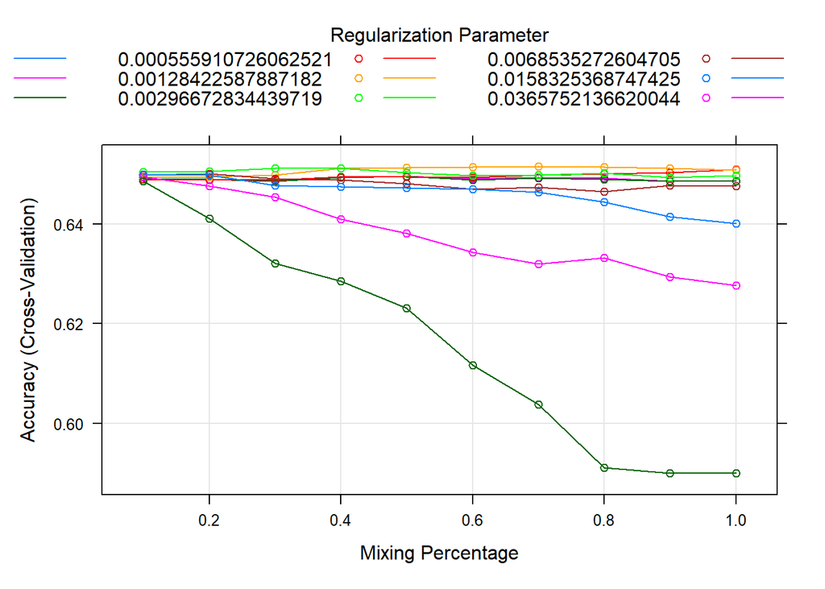

```r
plot(elasticOut)
```

```r
alphaHat         <- elasticOut$finalModel$tuneValue$alpha
lambdaHat        <- elasticOut$finalModel$tuneValue$lambda
cbind(alphaHat, lambdaHat)
```

```
##      alphaHat   lambdaHat
## [1,]      0.7 0.001284226
```

```r
glmnetOut        <- glmnet(x = XTrainRebalanced, y = lendingClubTrainRebalancedY$loan_status, alpha = alphaHat, standardize = FALSE, family = "binomial")
```

```r
probHatTest    <- predict(glmnetOut, as.matrix(XTest), s = lambdaHat, type = "response")
YHatTestGLMNET <- ifelse(probHatTest > 0.5, "Charged Off", "Paid Fully")
```

```r
confusionMatrix   <- table(YHatTestGLMNET, lendingClubTestY$loan_status)
confusionMatrix
```

```
##
## YHatTestGLMNET Charged Off Fully Paid
##    Charged Off         701       6854
##    Paid Fully         1219       3736
```

```r
sensitivity       <- confusionMatrix[1,1]/sum(confusionMatrix[,1])
specificity       <- confusionMatrix[2,2]/sum(confusionMatrix[,2])
precision         <- confusionMatrix[1,1]/sum(confusionMatrix[1,])

PredictionMetrics <- data.frame(sensitivity, specificity, precision)
PredictionMetrics
```

```
##   sensitivity specificity  precision
## 1   0.3651042   0.3527856 0.09278623
```

```r
YHatTestGLMNETNumeric = as.numeric(probHatTest)
roc  = roc(response = lendingClubTestY$loan_status, YHatTestGLMNETNumeric)
```

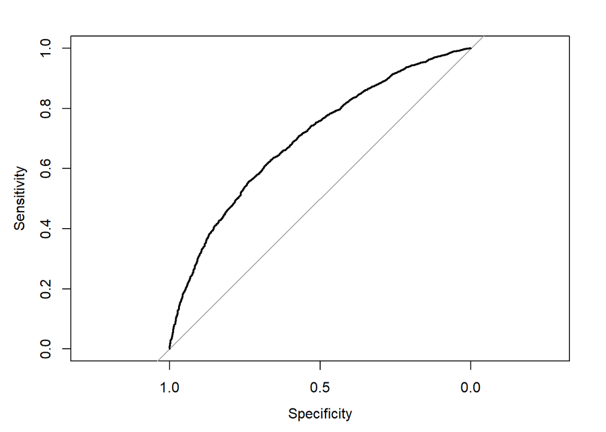

```r
plot(roc)
```

```r
roc$auc
```

```
## Area under the curve: 0.6983
```

### 3.a. Decision Tree (With original Training Data)

```r
set.seed(123)

trControl                 <- trainControl(method = "repeatedcv", repeats = 1, number = 10)

decicionTreeModelInf      <- train(
                                     x          = lendingClubTrainX
                                   , y          = lendingClubTrainY$loan_status
                                   , method     = "rpart"
                                   , tuneLength =  20
                                   , trControl  = trControl
                                   , parms      = list(split = "information")
                                   , metric     = 'Kappa'
                                  )

decicionTreeModelInf
```

```
## CART
##
## 29193 samples
##    19 predictor
##     2 classes: 'Charged Off', 'Fully Paid'
##
## No pre-processing
## Resampling: Cross-Validated (10 fold, repeated 1 times)
## Summary of sample sizes: 26273, 26274, 26274, 26274, 26273, 26274, ...
## Resampling results across tuning parameters:
##
##   cp            Accuracy   Kappa
##   0.0005419709  0.8346863  0.17293045
##   0.0005579112  0.8350288  0.17006883
##   0.0005802276  0.8358167  0.16594023
##   0.0005951053  0.8360565  0.16307149
##   0.0006248605  0.8369471  0.15941643
##   0.0006694934  0.8386599  0.15622859
##   0.0006973890  0.8391737  0.15249661
##   0.0007438816  0.8412291  0.15457745
##   0.0007587592  0.8415031  0.15579077
##   0.0007810757  0.8417087  0.15542826
##   0.0008926579  0.8432500  0.14281699
##   0.0010042401  0.8435582  0.13953783
##   0.0010711895  0.8440036  0.13726219
##   0.0011158224  0.8444833  0.13352639
##   0.0012274046  0.8450313  0.13036688
##   0.0013389868  0.8455451  0.12076044
##   0.0015621513  0.8453739  0.10680779
##   0.0017853158  0.8467443  0.10440949
##   0.0018968980  0.8468470  0.10382865
##   0.0024229286  0.8457851  0.08014765
##
## Kappa was used to select the optimal model using the largest value.
## The final value used for the model was cp = 0.0005419709.
```

[figure not shown]

```r
rpart.plot(decicionTreeModelInf$finalModel)
```

[figure not shown]

```r
plot(decicionTreeModelInf$finalModel,margin= rep(.1,4))
text(decicionTreeModelInf$finalModel, cex = 0.4, digits = 1)
```

```r
YHatDecisionTreeInf  <- predict(decicionTreeModelInf, lendingClubTestX)

confusionMatrixInf   <- table(YHatDecisionTreeInf, lendingClubTestY$loan_status)
confusionMatrixInf
```

```
##
## YHatDecisionTreeInf Charged Off Fully Paid
##         Charged Off         325        421
##         Fully Paid         1595      10169
```

```r
sensitivityInf       <- confusionMatrixInf[1,1]/sum(confusionMatrixInf[,1])
specificityInf       <- confusionMatrixInf[2,2]/sum(confusionMatrixInf[,2])
precisionInf         <- confusionMatrixInf[1,1]/sum(confusionMatrixInf[1,])

PredictionMetricsInf <- data.frame(sensitivityInf, specificityInf, precisionInf)
PredictionMetricsInf
```

```
##   sensitivityInf specificityInf precisionInf
## 1      0.1692708      0.9602455    0.4356568
```

```r
set.seed(123)

trControl                     <- trainControl(method = "repeatedcv", repeats = 1, number = 10)

decicionTreeModelGini         <- train(
                                         x          = lendingClubTrainX
                                       , y          = lendingClubTrainY$loan_status
                                       , method     = "rpart"
                                       , tuneLength =  20
                                       , trControl  = trControl
                                       , parms      = list(split = "gini")
                                       , metric     = 'Kappa'
                                      )


decicionTreeModelGini
```

```
## CART
##
## 29193 samples
##    19 predictor
##     2 classes: 'Charged Off', 'Fully Paid'
##
## No pre-processing
## Resampling: Cross-Validated (10 fold, repeated 1 times)
## Summary of sample sizes: 26273, 26274, 26274, 26274, 26273, 26274, ...
## Resampling results across tuning parameters:
##
##   cp            Accuracy   Kappa
##   0.0005419709  0.8308839  0.17155070
##   0.0005579112  0.8319116  0.17003317
##   0.0005802276  0.8335559  0.17038527
##   0.0005951053  0.8339669  0.16774231
##   0.0006248605  0.8349944  0.16639188
##   0.0006694934  0.8359192  0.16151020
##   0.0006973890  0.8360904  0.16003811
##   0.0007438816  0.8388994  0.15247671
##   0.0007587592  0.8388994  0.15171951
##   0.0007810757  0.8388994  0.15171951
##   0.0008926579  0.8422906  0.13865768
##   0.0010042401  0.8437636  0.13501263
##   0.0010711895  0.8439692  0.13469348
##   0.0011158224  0.8443118  0.12888093
##   0.0012274046  0.8446200  0.12238720
##   0.0013389868  0.8455107  0.12066423
##   0.0015621513  0.8463672  0.10980381
##   0.0017853158  0.8466756  0.10229324
##   0.0018968980  0.8465728  0.09681074
##   0.0024229286  0.8461276  0.08368190
##
## Kappa was used to select the optimal model using the largest value.
## The final value used for the model was cp = 0.0005419709.
```

[figure not shown]

```r
rpart.plot(decicionTreeModelGini$finalModel)
```

[figure not shown]

```r
plot(decicionTreeModelGini$finalModel,margin= rep(.1,4))
text(decicionTreeModelGini$finalModel, cex = 0.4, digits = 1)
```

```r
YHatDecisionTreeGini  <- predict(decicionTreeModelGini, lendingClubTestX)

confusionMatrixGini   <- table(YHatDecisionTreeGini, lendingClubTestY$loan_status)
confusionMatrixGini
```

```
##
## YHatDecisionTreeGini Charged Off Fully Paid
##          Charged Off         366        506
##          Fully Paid         1554      10084
```

```r
sensitivityGini       <- confusionMatrixGini[1,1]/sum(confusionMatrixGini[,1])
specificityGini       <- confusionMatrixGini[2,2]/sum(confusionMatrixGini[,2])
precisionGini         <- confusionMatrixGini[1,1]/sum(confusionMatrixGini[1,])

PredictionMetricsGini <- data.frame(sensitivityGini, specificityGini, precisionGini)
PredictionMetricsGini
```

```
##   sensitivityGini specificityGini precisionGini
## 1        0.190625       0.9522191     0.4197248
```

### 3.b. Decision Tree (With Rebalanced Training Data)

```r
set.seed(123)

trControl                 <- trainControl(method = "repeatedcv", repeats = 2, number = 10)

decicionTreeModelInf      <- train(
                                     x          = lendingClubTrainRebalancedXReduced
                                   , y          = lendingClubTrainRebalancedY$loan_status
                                   , method     = "rpart"
                                   , tuneLength =  20
                                   , trControl  = trControl
                                   , parms      = list(split = "information")
                                  )

decicionTreeModelInf
```

```
## CART
##
## 8962 samples
##   17 predictor
##    2 classes: 'Charged Off', 'Fully Paid'
##
## No pre-processing
## Resampling: Cross-Validated (10 fold, repeated 2 times)
## Summary of sample sizes: 8065, 8066, 8066, 8066, 8065, 8066, ...
## Resampling results across tuning parameters:
##
##   cp           Accuracy   Kappa
##   0.001041434  0.6847791  0.36955762
##   0.001115822  0.6856718  0.37134184
##   0.001338987  0.6868436  0.37368746
##   0.001413375  0.6868997  0.37380055
##   0.001487763  0.6883505  0.37670413
##   0.001562151  0.6887972  0.37759653
##   0.001710928  0.6899691  0.37994028
##   0.001896898  0.6933725  0.38674597
##   0.002082868  0.6933723  0.38674569
##   0.002120062  0.6940419  0.38808497
##   0.002231645  0.6943767  0.38875462
##   0.002343227  0.6946558  0.38931265
##   0.002901138  0.6943761  0.38875339
##   0.005244365  0.6847236  0.36944619
##   0.005355947  0.6834405  0.36688197
##   0.005579112  0.6803152  0.36062861
##   0.006025441  0.6773576  0.35471343
##   0.010935059  0.6734526  0.34690521
##   0.039723276  0.6384154  0.27681999
##   0.242133452  0.5480409  0.09613008
##
## Accuracy was used to select the optimal model using the largest value.
## The final value used for the model was cp = 0.002343227.
```

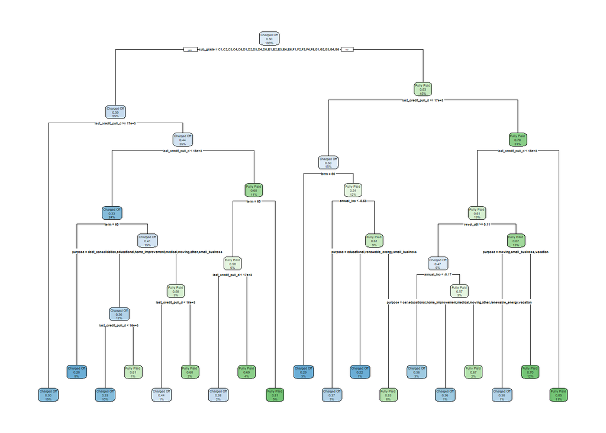

```r
rpart.plot(decicionTreeModelInf$finalModel)
```

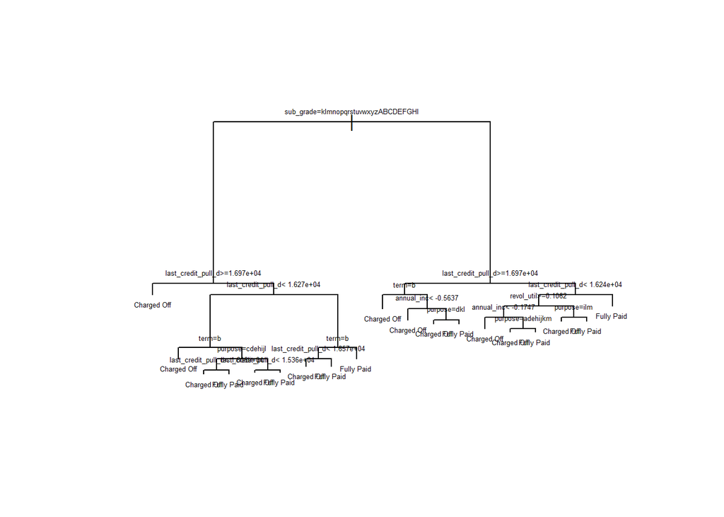

```r
plot(decicionTreeModelInf$finalModel,margin= rep(.1,4))
text(decicionTreeModelInf$finalModel, cex = 0.4, digits = 1)
```

```r
YHatDecisionTreeInf  <- predict(decicionTreeModelInf, lendingClubTestXReduced)

confusionMatrixInf   <- table(YHatDecisionTreeInf, lendingClubTestY$loan_status)
confusionMatrixInf
```

```
##
## YHatDecisionTreeInf Charged Off Fully Paid
##         Charged Off        1394       3687
##         Fully Paid          526       6903
```

```r
sensitivityInf       <- confusionMatrixInf[1,1]/sum(confusionMatrixInf[,1])
specificityInf       <- confusionMatrixInf[2,2]/sum(confusionMatrixInf[,2])
precisionInf         <- confusionMatrixInf[1,1]/sum(confusionMatrixInf[1,])

PredictionMetricsInf <- data.frame(sensitivityInf, specificityInf, precisionInf)
PredictionMetricsInf
```

```
##   sensitivityInf specificityInf precisionInf
## 1      0.7260417      0.6518414    0.2743554
```

```r
set.seed(123)

trControl                     <- trainControl(method = "repeatedcv", repeats = 2, number = 10)

decicionTreeModelGini         <- train(
                                         x          = lendingClubTrainRebalancedXReduced
                                       , y          = lendingClubTrainRebalancedY$loan_status
                                       , method     = "rpart"
                                       , tuneLength =  20
                                       , trControl  = trControl
                                       , parms      = list(split = "gini")
                                      )


decicionTreeModelGini
```

```
## CART
##
## 8962 samples
##   17 predictor
##    2 classes: 'Charged Off', 'Fully Paid'
##
## No pre-processing
## Resampling: Cross-Validated (10 fold, repeated 2 times)
## Summary of sample sizes: 8065, 8066, 8066, 8066, 8065, 8066, ...
## Resampling results across tuning parameters:
##
##   cp           Accuracy   Kappa
##   0.001041434  0.6848933  0.36978447
##   0.001115822  0.6869022  0.37380233
##   0.001338987  0.6876836  0.37536765
##   0.001413375  0.6882416  0.37648535
##   0.001487763  0.6873487  0.37469963
##   0.001562151  0.6881279  0.37625746
##   0.001710928  0.6900812  0.38016271
##   0.001896898  0.6933173  0.38663401
##   0.002082868  0.6938199  0.38763866
##   0.002120062  0.6936521  0.38730309
##   0.002231645  0.6935963  0.38719148
##   0.002343227  0.6940978  0.38819577
##   0.002901138  0.6943770  0.38875366
##   0.005244365  0.6837206  0.36744025
##   0.005355947  0.6813773  0.36275549
##   0.005579112  0.6797586  0.35951552
##   0.006025441  0.6765233  0.35304479
##   0.010935059  0.6736762  0.34735239
##   0.039723276  0.6370791  0.27414738
##   0.242133452  0.5480409  0.09613008
##
## Accuracy was used to select the optimal model using the largest value.
## The final value used for the model was cp = 0.002901138.
```

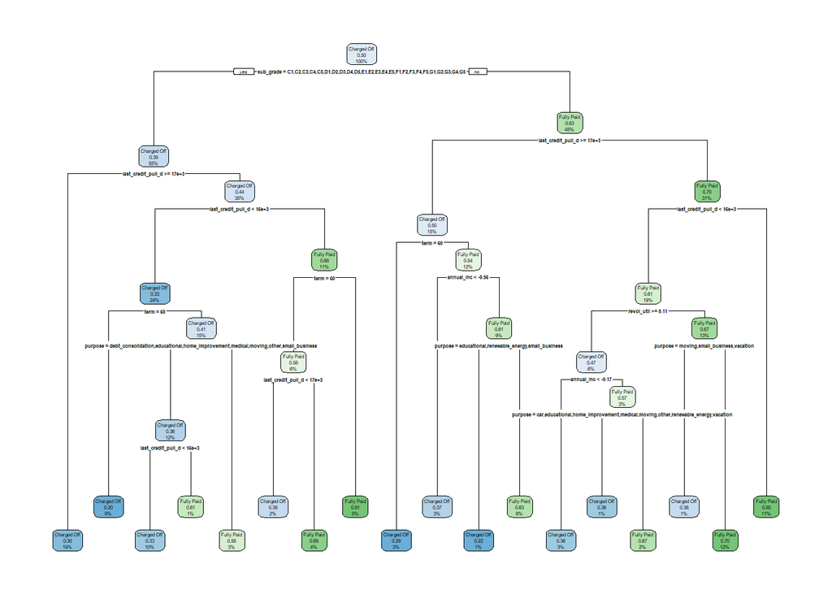

```r
rpart.plot(decicionTreeModelGini$finalModel)
```

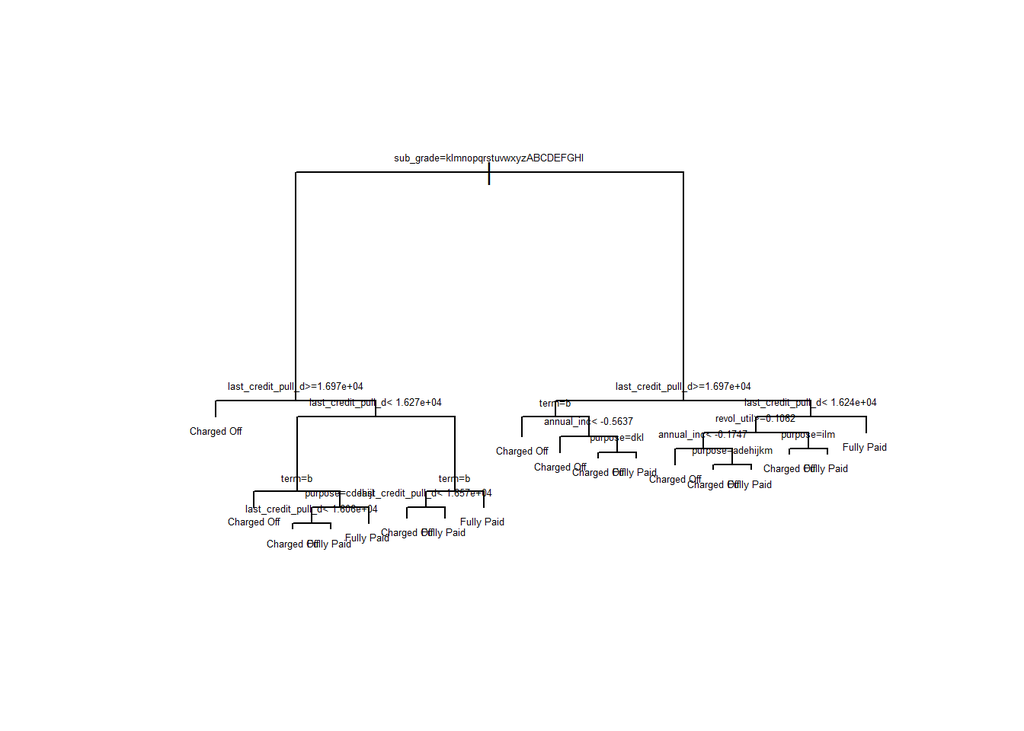

```r
plot(decicionTreeModelGini$finalModel,margin= rep(.1,4))
text(decicionTreeModelGini$finalModel, cex = 0.4, digits = 1)
```

```r
YHatDecisionTreeGini  <- predict(decicionTreeModelGini, lendingClubTestXReduced)

confusionMatrixGini   <- table(YHatDecisionTreeGini, lendingClubTestY$loan_status)
confusionMatrixGini
```

```
##
## YHatDecisionTreeGini Charged Off Fully Paid
##          Charged Off        1359       3583
##          Fully Paid          561       7007
```

```r
sensitivityGini       <- confusionMatrixGini[1,1]/sum(confusionMatrixGini[,1])
specificityGini       <- confusionMatrixGini[2,2]/sum(confusionMatrixGini[,2])
precisionGini         <- confusionMatrixGini[1,1]/sum(confusionMatrixGini[1,])

PredictionMetricsGini <- data.frame(sensitivityGini, specificityGini, precisionGini)
PredictionMetricsGini
```

```
##   sensitivityGini specificityGini precisionGini
## 1       0.7078125       0.6616619     0.2749899
```

### 4. Random Forest Model

```r
set.seed(123)

tuneGridRanger      <- data.frame(
                                   splitrule = "gini"
                                 , min.node.size = 5
                                 , mtry = round(sqrt(ncol(lendingClubTrainRebalancedX)))
                                 )

tuneGridRanger      <- expand.grid(
                                   splitrule     = c("gini", "extratrees")
                                 , min.node.size = c(1, 3, 5, 7)
                                 , mtry          = c(2, 3, 4, 5)
                                 )

trControl           <- trainControl(method = "repeatedcv", repeats = 1, number = 10)

randomForestModel   <- train(
                              x         = lendingClubTrainRebalancedXReduced
                            , y         = lendingClubTrainRebalancedY$loan_status
                            , method    = "ranger"
                            , tuneGrid  = tuneGridRanger
                            , trControl = trControl
                           )

randomForestModel
```

```
## Random Forest
##
## 8962 samples
##   17 predictor
##    2 classes: 'Charged Off', 'Fully Paid'
##
## No pre-processing
## Resampling: Cross-Validated (10 fold, repeated 1 times)
## Summary of sample sizes: 8065, 8066, 8066, 8066, 8065, 8066, ...
## Resampling results across tuning parameters:
##
##   splitrule   min.node.size  mtry  Accuracy   Kappa
##   gini        1              2     0.7029672  0.4059274
##   gini        1              3     0.7076545  0.4153011
##   gini        1              4     0.7093281  0.4186507
##   gini        1              5     0.7118949  0.4237838
##   gini        3              2     0.7036358  0.4072655
##   gini        3              3     0.7063148  0.4126213
##   gini        3              4     0.7122303  0.4244542
##   gini        3              5     0.7140155  0.4280252
##   gini        5              2     0.7051991  0.4103928
##   gini        5              3     0.7091039  0.4182015
##   gini        5              4     0.7108900  0.4217737
##   gini        5              5     0.7124532  0.4249004
##   gini        7              2     0.7046425  0.4092758
##   gini        7              3     0.7103323  0.4206564
##   gini        7              4     0.7094391  0.4188726
##   gini        7              5     0.7129005  0.4257956
##   extratrees  1              2     0.6588885  0.3177721
##   extratrees  1              3     0.6764073  0.3528095
##   extratrees  1              4     0.6854472  0.3708861
##   extratrees  1              5     0.6919184  0.3838287
##   extratrees  3              2     0.6624582  0.3249128
##   extratrees  3              3     0.6751792  0.3503525
##   extratrees  3              4     0.6839955  0.3679842
##   extratrees  3              5     0.6894631  0.3789188
##   extratrees  5              2     0.6591116  0.3182182
##   extratrees  5              3     0.6805356  0.3610651
##   extratrees  5              4     0.6855579  0.3711099
##   extratrees  5              5     0.6911375  0.3822679
##   extratrees  7              2     0.6558751  0.3117471
##   extratrees  7              3     0.6768541  0.3537004
##   extratrees  7              4     0.6837722  0.3675382
##   extratrees  7              5     0.6913602  0.3827136
##
## Accuracy was used to select the optimal model using the largest value.
## The final values used for the model were mtry = 5, splitrule = gini
##  and min.node.size = 3.
```

```r
YHatRandomForest  <- predict(randomForestModel, lendingClubTestXReduced)

confusionMatrixRandomForest   <- table(YHatRandomForest, lendingClubTestY$loan_status)
confusionMatrixRandomForest
```

```
##
## YHatRandomForest Charged Off Fully Paid
##      Charged Off        1407       3358
##      Fully Paid          513       7232
```

```r
sensitivityRandomForest       <- confusionMatrixRandomForest[1,1]/sum(confusionMatrixRandomForest[,1])
specificityRandomForest       <- confusionMatrixRandomForest[2,2]/sum(confusionMatrixRandomForest[,2])
precisionRandomForest         <- confusionMatrixRandomForest[1,1]/sum(confusionMatrixRandomForest[1,])

PredictionMetricsRandomForest <- data.frame(sensitivityRandomForest, specificityRandomForest, precisionRandomForest)
PredictionMetricsRandomForest
```

```
##   sensitivityRandomForest specificityRandomForest precisionRandomForest
## 1               0.7328125               0.6829084             0.2952781
```

```r
set.seed(123)

trControl           <- trainControl(method = "repeatedcv", repeats = 1, number = 10)

randomForestModel_2   <- train(
                                x          = lendingClubTrainRebalancedXReduced
                              , y          = lendingClubTrainRebalancedY$loan_status
                              , method     = "rf"
                              , tuneLength = 10
                              , ntree      = 100
                              , importance = TRUE
                              #, metric     = 'Kappa'
                              , trControl = trControl
                              )

randomForestModel_2
```

```
## Random Forest
##
## 8962 samples
##   17 predictor
##    2 classes: 'Charged Off', 'Fully Paid'
##
## No pre-processing
## Resampling: Cross-Validated (10 fold, repeated 1 times)
## Summary of sample sizes: 8065, 8066, 8066, 8066, 8065, 8066, ...
## Resampling results across tuning parameters:
##
##   mtry  Accuracy   Kappa
##    2    0.6796444  0.3592866
##    3    0.6906928  0.3813813
##    5    0.7015132  0.4030252
##    7    0.7036344  0.4072652
##    8    0.6989485  0.3978933
##   10    0.7054215  0.4108377
##   12    0.6998421  0.3996809
##   13    0.7016256  0.4032495
##   15    0.6990609  0.3981197
##   17    0.6970535  0.3941057
##
## Accuracy was used to select the optimal model using the largest value.
## The final value used for the model was mtry = 10.
```

```r
YHatRandomForest_2  <- predict(randomForestModel_2, lendingClubTestXReduced)

confusionMatrixRandomForest_2   <- table(YHatRandomForest_2, lendingClubTestY$loan_status)
confusionMatrixRandomForest_2
```

```
##
## YHatRandomForest_2 Charged Off Fully Paid
##        Charged Off        1312       3025
##        Fully Paid          608       7565
```

```r
sensitivityRandomForest_2       <- confusionMatrixRandomForest_2[1,1]/sum(confusionMatrixRandomForest_2[,1])
specificityRandomForest_2       <- confusionMatrixRandomForest_2[2,2]/sum(confusionMatrixRandomForest_2[,2])
precisionRandomForest_2         <- confusionMatrixRandomForest_2[1,1]/sum(confusionMatrixRandomForest_2[1,])

PredictionMetricsRandomForest_2 <- data.frame(sensitivityRandomForest_2, specificityRandomForest_2, precisionRandomForest_2)
PredictionMetricsRandomForest_2
```

```
##   sensitivityRandomForest_2 specificityRandomForest_2 precisionRandomForest_2
## 1                 0.6833333                 0.7143532               0.3025133
```

### 5. Boosting Model

```r
XTrain = sparse.model.matrix(loan_status ~., data = lendingClubTrainRebalancedReduced)
XTest  = sparse.model.matrix(loan_status ~., data = lendingClubTestReduced)
```

```r
set.seed(123)

trainControl = trainControl(method = "repeatedcv", repeats = 1, number = 10, verboseIter = FALSE)

B = seq(100,500,length.out = 10)

tuneGrid = data.frame(
                        'nrounds'          = B
                      , 'max_depth'        = 6
                      , 'eta'              = .01
                      , 'gamma'            = 0
                      , 'colsample_bytree' = 1
                      , 'min_child_weight' = 0
                      , 'subsample'        = 0.5
                      #, 'objective'        = "binary:logistic" #reg:logistic
                      #, 'eval_metric'      = "logloss" #error, error@t, auc
                     )

xgBoostModel <- train(
                        x           = XTrain
                      , y           = lendingClubTrainRebalancedY$loan_status
                      , method      = "xgbTree"
                      , tuneGrid    = tuneGrid
                      , trControl   = trainControl
                      , objective   = "binary:logistic"
                      , eval_metric = "logloss"
                      #, metric = 'Accuracy'
                     )
```

[output not shown]

[output not shown]

[output not shown]

[output not shown]

[output not shown]

[output not shown]

[output not shown]

[output not shown]

[output not shown]

[output not shown]

```r
YhatXGBoost  <- predict(xgBoostModel, XTest)
```

```r
confusionMatrixXGBoost   <- table(YhatXGBoost, lendingClubTestY$loan_status)
confusionMatrixXGBoost
```

```
##
## YhatXGBoost   Charged Off Fully Paid
##   Charged Off        1413       3319
##   Fully Paid          507       7271
```

```r
sensitivityXGBoost       <- confusionMatrixXGBoost[1,1]/sum(confusionMatrixXGBoost[,1])
specificityXGBoost       <- confusionMatrixXGBoost[2,2]/sum(confusionMatrixXGBoost[,2])
precisionXGBoost         <- confusionMatrixXGBoost[1,1]/sum(confusionMatrixXGBoost[1,])

PredictionMetricsXGBoost <- data.frame(sensitivityXGBoost, specificityXGBoost, precisionXGBoost)
PredictionMetricsXGBoost
```

```
##   sensitivityXGBoost specificityXGBoost precisionXGBoost
## 1          0.7359375          0.6865911        0.2986052
```

```r
YhatXGBoost = as.numeric(YhatXGBoost)
rocXGBoost = roc(response = lendingClubTestY$loan_status, YhatXGBoost)
```

```r
plot(rocXGBoost)
```

[output not shown]

```r
rocXGBoost$auc
```

```
## Area under the curve: 0.7113
```

```r
set.seed(123)

trainControl = trainControl(method = "repeatedcv", repeats = 1, number = 10, verboseIter = FALSE)

B = seq(100,500,length.out = 10)

tuneGrid = data.frame(
                        'nrounds'          = B
                      , 'max_depth'        = 6
                      , 'eta'              = .01
                      , 'gamma'            = 0
                      , 'colsample_bytree' = 1
                      , 'min_child_weight' = 0
                      , 'subsample'        = 0.5
                      #, 'objective'        = "binary:logistic" #reg:logistic
                      #, 'eval_metric'      = "error" #logloss, error, error@t, auc
                     )

xgBoostModel2 <- train(
                         x           = XTrain
                       , y           = lendingClubTrainRebalancedY$loan_status
                       , method      = "xgbTree"
                       , tuneGrid    = tuneGrid
                       , trControl   = trainControl
                       , objective   = "binary:logistic"
                       , eval_metric = "error"
                       #, metric = 'Accuracy'
                     )
```

[output not shown]

[output not shown]

[output not shown]

[output not shown]

[output not shown]

[output not shown]

[output not shown]

[output not shown]

[output not shown]

[output not shown]

```r
YhatXGBoost2  <- predict(xgBoostModel2, XTest)
```

```r
confusionMatrixXGBoost2   <- table(YhatXGBoost2, lendingClubTestY$loan_status)
confusionMatrixXGBoost2
```

```
##
## YhatXGBoost2  Charged Off Fully Paid
##   Charged Off        1413       3319
##   Fully Paid          507       7271
```

```r
sensitivityXGBoost2       <- confusionMatrixXGBoost2[1,1]/sum(confusionMatrixXGBoost2[,1])
specificityXGBoost2       <- confusionMatrixXGBoost2[2,2]/sum(confusionMatrixXGBoost2[,2])
precisionXGBoost2         <- confusionMatrixXGBoost2[1,1]/sum(confusionMatrixXGBoost2[1,])

PredictionMetricsXGBoost2 <- data.frame(sensitivityXGBoost2, specificityXGBoost2, precisionXGBoost2)
PredictionMetricsXGBoost2
```

```
##   sensitivityXGBoost2 specificityXGBoost2 precisionXGBoost2
## 1           0.7359375           0.6865911         0.2986052
```

```r
YhatXGBoost2 = as.numeric(YhatXGBoost2)
rocXGBoost2 = roc(response = lendingClubTestY$loan_status, YhatXGBoost2)
```

```r
plot(rocXGBoost2)
```

[output not shown]

```r
rocXGBoost2$auc
```

```
## Area under the curve: 0.7113
```

```r
set.seed(123)

trainControl = trainControl(method = "repeatedcv", repeats = 1, number = 10, verboseIter = FALSE)

B = seq(100,500,length.out = 10)

tuneGrid = data.frame(
                        'nrounds'          = B
                      , 'max_depth'        = 6
                      , 'eta'              = .01
                      , 'gamma'            = 0
                      , 'colsample_bytree' = 1
                      , 'min_child_weight' = 0
                      , 'subsample'        = 0.5
                      #, 'objective'        = "binary:logistic" #reg:logistic
                      #, 'eval_metric'      = "error" #logloss, error, error@t, auc
                     )

xgBoostModel3 <- train(
                         x           = XTrain
                       , y           = lendingClubTrainRebalancedY$loan_status
                       , method      = "xgbTree"
                       , tuneGrid    = tuneGrid
                       , trControl   = trainControl
                       #, metric = 'Accuracy'
                     )
```

[output not shown]

[output cut: 35 more lines]

[output not shown]

```r
YhatXGBoost3  <- predict(xgBoostModel3, XTest)
```

```r
confusionMatrixXGBoost3   <- table(YhatXGBoost3, lendingClubTestY$loan_status)
confusionMatrixXGBoost3
```

```
##
## YhatXGBoost3  Charged Off Fully Paid
##   Charged Off        1413       3319
##   Fully Paid          507       7271
```

```r
sensitivityXGBoost3       <- confusionMatrixXGBoost3[1,1]/sum(confusionMatrixXGBoost3[,1])
specificityXGBoost3       <- confusionMatrixXGBoost3[2,2]/sum(confusionMatrixXGBoost3[,2])
precisionXGBoost3         <- confusionMatrixXGBoost3[1,1]/sum(confusionMatrixXGBoost3[1,])

PredictionMetricsXGBoost3 <- data.frame(sensitivityXGBoost3, specificityXGBoost3, precisionXGBoost3)
PredictionMetricsXGBoost3
```

```
##   sensitivityXGBoost3 specificityXGBoost3 precisionXGBoost3
## 1           0.7359375           0.6865911         0.2986052
```

```r
YhatXGBoost3 = as.numeric(YhatXGBoost3)
rocXGBoost3 = roc(response = lendingClubTestY$loan_status, YhatXGBoost3)
```

```r
plot(rocXGBoost3)
```

[output not shown]

```r
rocXGBoost3$auc
```

```
## Area under the curve: 0.7113
```

### Variable Importance

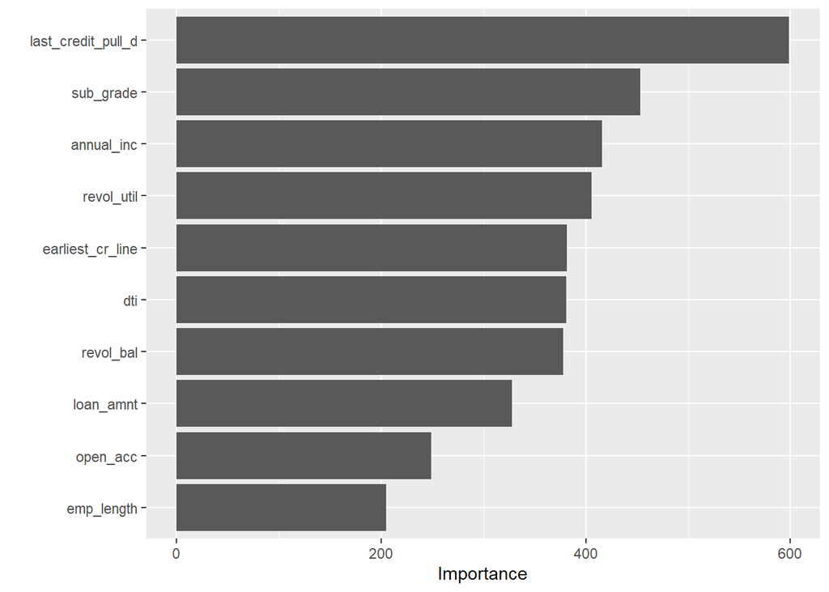

```r
library(vip)
output.forest <- ranger(loan_status~., data = lendingClubTrainRebalancedReduced, importance = 'impurity')
vi_tree <- vip(output.forest)
vi_tree
```

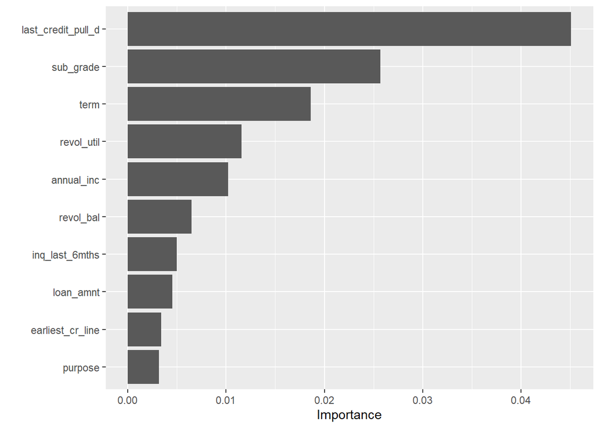

```r
library(vip)
output.forest <- ranger(loan_status~., data = lendingClubTrainRebalancedReduced, importance = 'permutation')
vi_tree <- vip(output.forest)
vi_tree
```

```r
boostImportance0 = xgb.importance(model = xgBoostModel$finalModel)
boostImportance0
```

```
##                       Feature         Gain        Cover    Frequency
##  1:        last_credit_pull_d 2.572141e-01 1.970218e-01 1.159543e-01
##  2:                revol_util 9.102084e-02 8.776645e-02 9.699295e-02
##  3:                annual_inc 9.011669e-02 1.007522e-01 9.302222e-02
##  4:                    term60 7.113675e-02 7.083811e-02 1.722138e-02
##  5:          earliest_cr_line 6.663739e-02 6.250804e-02 8.735612e-02
##  6:                 revol_bal 6.085268e-02 5.033576e-02 7.825466e-02
##  7:                       dti 5.747270e-02 4.462765e-02 9.717141e-02
##  8:            inq_last_6mths 5.076067e-02 6.427835e-02 3.988579e-02
##  9:                 loan_amnt 5.062100e-02 4.570828e-02 9.195146e-02
## 10:                  open_acc 2.874438e-02 2.170236e-02 4.916570e-02
## 11:     purposesmall_business 1.798199e-02 3.482084e-02 1.177835e-02
## 12:      IsLoanMeetsPolicyYes 1.656085e-02 1.339881e-02 7.539930e-03
## 13:               delinq_2yrs 9.994940e-03 1.602566e-02 1.445525e-02
## 14:     purposemajor_purchase 7.777516e-03 1.389978e-02 8.566075e-03
```

[output cut: 60 more lines]

```r
caret::varImp(xgBoostModel)
```

```
## xgbTree variable importance
##
##   only 20 most important variables shown (out of 75)
##
##                           Overall
## last_credit_pull_d        100.000
## revol_util                 35.387
## annual_inc                 35.036
## term60                     27.657
## earliest_cr_line           25.907
## revol_bal                  23.658
## dti                        22.344
## inq_last_6mths             19.735
## loan_amnt                  19.680
## open_acc                   11.175
## purposesmall_business       6.991
## IsLoanMeetsPolicyYes        6.439
## delinq_2yrs                 3.886
## purposemajor_purchase       3.024
## purposecredit_card          2.802
## emp_length10                2.533
## pub_rec                     2.505
## home_ownershipRENT          2.500
## sub_gradeB5                 1.927
## purposedebt_consolidation   1.810
```

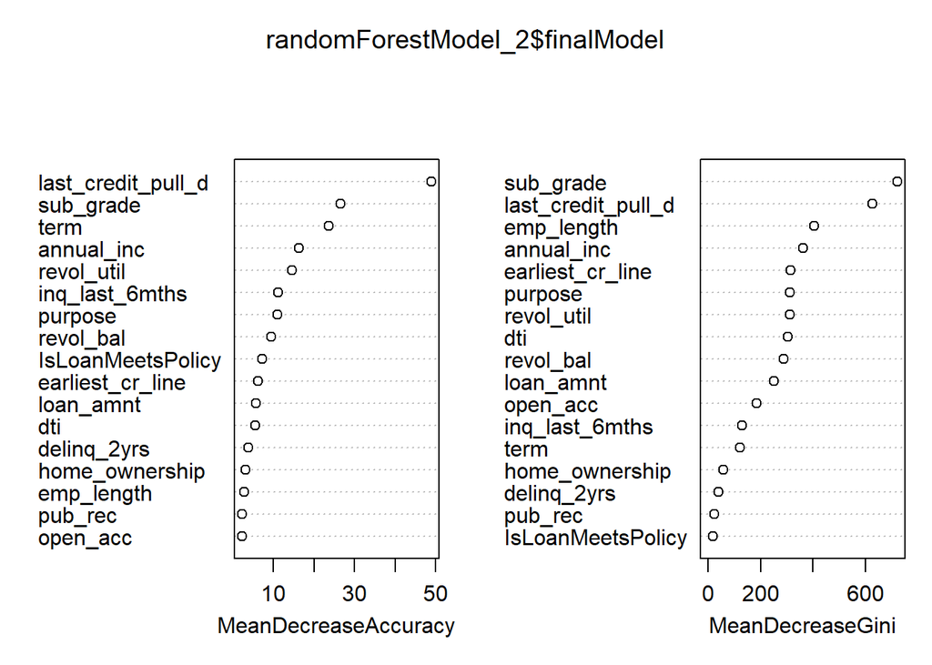

```r
varImpPlot(randomForestModel_2$finalModel)
```

```r
caret::varImp(randomForestModel_2$finalModel)
```

```
##                    Charged Off Fully Paid
## loan_amnt             3.801992   3.801992
## dti                   3.466777   3.466777
## delinq_2yrs           2.747108   2.747108
## inq_last_6mths        7.196816   7.196816
## open_acc              1.463434   1.463434
## pub_rec               1.431968   1.431968
## revol_util           10.586250  10.586250
## annual_inc           11.131001  11.131001
## revol_bal             6.053047   6.053047
## term                 16.388403  16.388403
## sub_grade            16.156189  16.156189
## emp_length            1.994100   1.994100
## home_ownership        2.385165   2.385165
## purpose               7.068601   7.068601
## earliest_cr_line      4.271496   4.271496
## last_credit_pull_d   35.484888  35.484888
## IsLoanMeetsPolicy     4.827814   4.827814
```

```r
YHatDecisionTreeInfProb           <- predict(decicionTreeModelInf, lendingClubTestXReduced, type = "prob")

YhatDecisionTreeNewT              <- ifelse(YHatDecisionTreeInfProb$`Charged Off` > .3, 'Charged Off', 'Fully Paid') %>% as.factor

confusionMatrixDecisionTreeNewT   <- table(YhatDecisionTreeNewT, lendingClubTestY$loan_status)
confusionMatrixDecisionTreeNewT
```

```
##
## YhatDecisionTreeNewT Charged Off Fully Paid
##          Charged Off        1818       7634
##          Fully Paid          102       2956
```

```r
sensitivityDecisionTreeNewT       <- confusionMatrixDecisionTreeNewT[1,1]/sum(confusionMatrixDecisionTreeNewT[,1])
specificityDecisionTreeNewT       <- confusionMatrixDecisionTreeNewT[2,2]/sum(confusionMatrixDecisionTreeNewT[,2])
precisionDecisionTreeNewT         <- confusionMatrixDecisionTreeNewT[1,1]/sum(confusionMatrixDecisionTreeNewT[1,])

PredictionMetricsDecisionTreeNewT <- data.frame(sensitivityDecisionTreeNewT, specificityDecisionTreeNewT, precisionDecisionTreeNewT)
PredictionMetricsDecisionTreeNewT
```

```
##   sensitivityDecisionTreeNewT specificityDecisionTreeNewT
## 1                    0.946875                   0.2791313
##   precisionDecisionTreeNewT
## 1                 0.1923402
```

```r
YhatDecisionNewTNumeric = as.numeric(YhatDecisionTreeNewT)
rocDecisionTreeNewT = roc(response = lendingClubTestY$loan_status, YhatDecisionNewTNumeric)
```

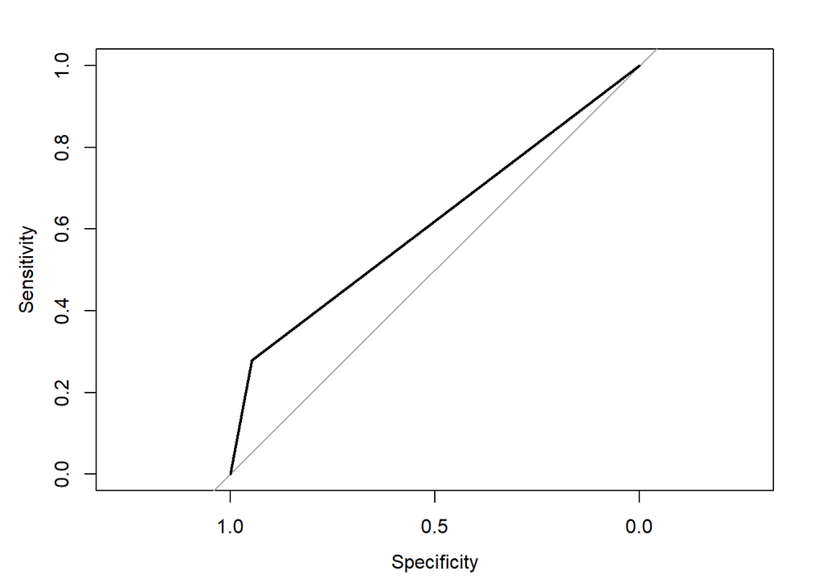

```r
plot(rocDecisionTreeNewT)
```

```r
rocDecisionTreeNewT$auc
```

```
## Area under the curve: 0.613
```

```r
confusionMatrix(data = YhatDecisionTreeNewT, ref = lendingClubTestY$loan_status)
```

```
## Confusion Matrix and Statistics
##
##              Reference
## Prediction    Charged Off Fully Paid
##   Charged Off        1818       7634
##   Fully Paid          102       2956
##
##                Accuracy : 0.3816
##                  95% CI : (0.3731, 0.3902)
##     No Information Rate : 0.8465
##     P-Value [Acc > NIR] : 1
##
##                   Kappa : 0.0867
##
##  Mcnemar's Test P-Value : <2e-16
##
##             Sensitivity : 0.9469
##             Specificity : 0.2791
##          Pos Pred Value : 0.1923
##          Neg Pred Value : 0.9666
##              Prevalence : 0.1535
##          Detection Rate : 0.1453
##    Detection Prevalence : 0.7556
##       Balanced Accuracy : 0.6130
##
##        'Positive' Class : Charged Off
##
```

```r
YhatXGBoostProb  <- predict(xgBoostModel, XTest, type = "prob")


#nrow(YhatXGBoostProb[which(YhatXGBoostProb$`Charged Off` > 0.5),])
#nrow(YhatXGBoostProb[which(YhatXGBoostProb$`Charged Off` > 0.45),])
#nrow(YhatXGBoostProb[which(YhatXGBoostProb$`Charged Off` > 0.4),])

YhatXGBoostNewT              <- ifelse(YhatXGBoostProb$`Charged Off` > .4, 'Charged Off', 'Fully Paid') %>% as.factor


confusionMatrixXGBoostNewT   <- table(YhatXGBoostNewT, lendingClubTestY$loan_status)
confusionMatrixXGBoostNewT
```

```
##
## YhatXGBoostNewT Charged Off Fully Paid
##     Charged Off        1617       4804
##     Fully Paid          303       5786
```

```r
sensitivityXGBoostNewT       <- confusionMatrixXGBoostNewT[1,1]/sum(confusionMatrixXGBoostNewT[,1])
specificityXGBoostNewT       <- confusionMatrixXGBoostNewT[2,2]/sum(confusionMatrixXGBoostNewT[,2])
precisionXGBoostNewT         <- confusionMatrixXGBoostNewT[1,1]/sum(confusionMatrixXGBoostNewT[1,])

PredictionMetricsXGBoostNewT <- data.frame(sensitivityXGBoostNewT, specificityXGBoostNewT, precisionXGBoostNewT)
PredictionMetricsXGBoostNewT
```

```
##   sensitivityXGBoostNewT specificityXGBoostNewT precisionXGBoostNewT
## 1              0.8421875              0.5463645            0.2518299
```

```r
YhatXGBoostNewTNumeric = as.numeric(YhatXGBoostNewT)
rocXGBoostNewT = roc(response = lendingClubTestY$loan_status, YhatXGBoostNewTNumeric)
```

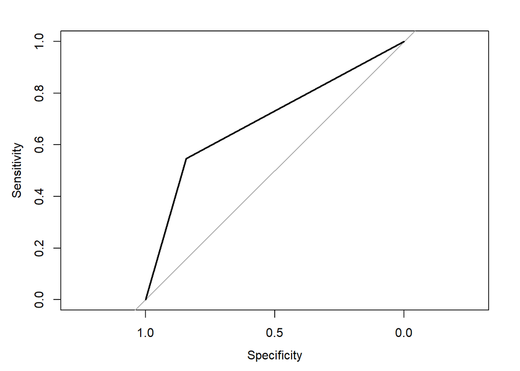

```r
plot(rocXGBoostNewT)
```

```r
rocXGBoostNewT$auc
```

```
## Area under the curve: 0.6943
```

```r
confusionMatrix(data = YhatXGBoostNewT, ref = lendingClubTestY$loan_status)
```

```
## Confusion Matrix and Statistics
##
##              Reference
## Prediction    Charged Off Fully Paid
##   Charged Off        1617       4804
##   Fully Paid          303       5786
##
##                Accuracy : 0.5918
##                  95% CI : (0.5831, 0.6004)
##     No Information Rate : 0.8465
##     P-Value [Acc > NIR] : 1
##
##                   Kappa : 0.1983
##
##  Mcnemar's Test P-Value : <2e-16
##
##             Sensitivity : 0.8422
##             Specificity : 0.5464
##          Pos Pred Value : 0.2518
##          Neg Pred Value : 0.9502
##              Prevalence : 0.1535
##          Detection Rate : 0.1293
##    Detection Prevalence : 0.5133
##       Balanced Accuracy : 0.6943
##
##        'Positive' Class : Charged Off
##
```